# Group 3

### Daniel O'Brien: dobrie22@depaul.edu

### Samuel Hoppen: shoppen@depaul.edu

### Christopher Wieneke: cwienek1@depaul.edu

### Zhong Xie: zxie8@depaul.edu

# Abstract

Our motivation for this project stems from identifying factors that lead to successful passing plays in the NFL. Specifically, we will be examining which route combinations are most effective in general, and which route combinations are most effective against specifc coverage schemes, how different passing nuances, such as drop type and RPO (run-pass option) impact a play's level of success, which route combinations are most likely to be interceptedand what other factors lead to an interception, and which coverage schemes are most effective against specific route combinations. The questions are addressed through a variety of machine learning models. We found that the combination of Curl, Curl, Go, Out and Swing routes were more successful than all other route combinations. We also saw that trick plays improve the odds of success in terms of drop back models, but this could be due to how infrequently trick plays are run. When analyzing defensive coverages, the defensive coverage scheme of Cover 3 was most effective against the route combination of Dig, Drag, Go and Post routes. The screen coverage scheme was also seen to be effective against a variety of route combinations. When examining the classification of interceptions on plays, Yard line, Presure on Play and Time Left (in the game) were the most influential factors. Additionally, Flat, Corner, and Go routes were the most influential passing routes and Cover 0, Cover 2, and Cover 3 were the most influential coverage schemes.

# 1. Introduction

Overall, our goal of the project was to evaluate and identify what the most effective passing strategies in the NFL are. This included evaluating different route concepts and coverage schemes to see which offer the highest expected value for an offense as well as how different factors influence the outcome of a play.

These results could help NFL teams optimize their passing-game strategy while providing some insights into different ways to leverage unique schemes and coverages. In the end, there are four key research questions that we hope to answer through different machine learning techniques:

1. Which route combinations are most effective? Which route combinations are most effective against specific coverage schemes?
2. Do different passing nuances (i.e., drop type, RPO) significantly impact a play’s level of success?
3. Which route (or route combinations) are most likely to be intercepted? What factors are most likely to lead to an interception?
4. Which coverage schemes are most effective on defense? Which coverage schemes are most effective against specific route combinations?

Before answering those questions, we set out to explore our data and will provide some foundational knowledge on the dataset that we used.

# 2. Exploratory Data Analysis

```python
# import libraries
import pandas as pd
import numpy as np
import matplotlib.pyplot as plt
import seaborn as sns
import sklearn
import random
from sklearn.svm import SVC
from sklearn.tree import DecisionTreeClassifier, plot_tree
from sklearn.model_selection import train_test_split
from sklearn import metrics
from sklearn import tree
from sklearn.linear_model import LogisticRegression
from sklearn.metrics import confusion_matrix, ConfusionMatrixDisplay
from sklearn.model_selection import GridSearchCV
from sklearn.metrics import balanced_accuracy_score
random.seed(123)
```

## Data Cleaning

```python
# load the data for our analysis
pbp = pd.read_csv("https://raw.githubusercontent.com/samhoppen/DSC-540-Group-Project/main/SIS%20PBP.csv")
game_info = pd.read_csv("https://raw.githubusercontent.com/samhoppen/DSC-540-Group-Project/main/SIS%20Game%20Info.csv")
player_positions = pd.read_csv("https://raw.githubusercontent.com/samhoppen/DSC-540-Group-Project/main/SIS%20Player%20Positions.csv")
pd.set_option('max_columns', None)
```

While we have loaded three datasets, the primary dataset we will be using (and first exploring), is the player_positions file. Below is a preview of the data, which includes 13 variables and over 190,000 observations. This datset outlines each of the routes run by individual players throughout the season.

```python
player_positions.info()
```

```
<class 'pandas.core.frame.DataFrame'>
RangeIndex: 192988 entries, 0 to 192987
Data columns (total 13 columns):
 #   Column                 Non-Null Count   Dtype
---  ------                 --------------   -----
 0   GameID                 192988 non-null  int64
 1   EventID                192988 non-null  int64
 2   PlayerId               192988 non-null  int64
 3   Name                   192988 non-null  object
 4   RosterPosition         192988 non-null  object
 5   OnFieldPosition        192988 non-null  object
 6   SideOfCenter           126795 non-null  object
 7   Order_OutsideToInside  126795 non-null  float64
 8   IsBlocking             192988 non-null  int64
 9   Route                  93055 non-null   object
 10  FastMotion             192988 non-null  int64
 11  Target                 192988 non-null  int64
 12  Reception              192988 non-null  int64
dtypes: float64(1), int64(7), object(5)
memory usage: 19.1+ MB
```

```python
player_positions.head(10)
```

|  | GameID | EventID | PlayerId | Name | RosterPosition | OnFieldPosition | SideOfCenter | Order_OutsideToInside | IsBlocking | Route | FastMotion | Target | Reception |
| --- | --- | --- | --- | --- | --- | --- | --- | --- | --- | --- | --- | --- | --- |
| 0 | 2793 | 10 | 3951 | Will Fuller V | WR | WR | L | 1.0 | 0 | NaN | 0 | 0 | 0 |
| 1 | 2793 | 10 | 876 | Brandin Cooks | WR | SWR | L | 2.0 | 0 | NaN | 0 | 0 | 0 |
| 2 | 2793 | 10 | 6528 | Jordan Akins | TE | TE | R | 1.0 | 0 | NaN | 0 | 0 | 0 |
| 3 | 2793 | 10 | 1430 | Darren Fells | TE | TE | R | 2.0 | 0 | NaN | 0 | 0 | 0 |
| 4 | 2793 | 10 | 2455 | David Johnson | RB | B | NaN | NaN | 0 | NaN | 0 | 0 | 0 |
| 5 | 2793 | 10 | 4840 | Deshaun Watson | QB | QB | NaN | NaN | 0 | NaN | 0 | 0 | 0 |
| 6 | 2793 | 15 | 3951 | Will Fuller V | WR | SWR | L | 1.0 | 0 | Fade - Back Shoulder | 0 | 1 | 0 |
| 7 | 2793 | 15 | 6528 | Jordan Akins | TE | TE | L | 2.0 | 0 | Curl | 0 | 0 | 0 |
| 8 | 2793 | 15 | 876 | Brandin Cooks | WR | SWR | R | 1.0 | 0 | Go/Fly | 0 | 0 | 0 |
| 9 | 2793 | 15 | 1430 | Darren Fells | TE | TE | R | 2.0 | 0 | Out | 0 | 0 | 0 |

The play by play dataset contains about 32,000 rows each representing a single play in the 2020-2021 NFL season

```python
pbp.head()
```

|  | GameID | EventID | Season | Week | OffensiveTeam | DefensiveTeam | OffTeamScoreBefore | DefTeamScoreBefore | Quarter | TimeLeft | Down | ToGo | SideOfField | StartYard | Hash | EventType | FirstDown | Touchdown | Safety | Turnover | Attempt | Completion | Spike | ThrowAway | ThrowDepth | Shotgun | DropType | RPO | CoverageScheme | … |
| --- | --- | --- | --- | --- | --- | --- | --- | --- | --- | --- | --- | --- | --- | --- | --- | --- | --- | --- | --- | --- | --- | --- | --- | --- | --- | --- | --- | --- | --- | --- |
| 0 | 2793 | 10 | 2020 | 1 | Texans | Chiefs | 0 | 0 | 1 | 900 | 1 | 10 | Own | 25 | 3 | rush | 0 | 0 | 0 | 0 | NaN | NaN | NaN | NaN | NaN | 1 | NaN | 0 | NaN | … |
| 1 | 2793 | 15 | 2020 | 1 | Texans | Chiefs | 0 | 0 | 1 | 866 | 2 | 5 | Own | 30 | 3 | pass | 0 | 0 | 0 | 0 | 1.0 | 0.0 | 0.0 | 0.0 | 18.0 | 1 | 3 Step | 0 | Cover 1 | … |
| 2 | 2793 | 25 | 2020 | 1 | Texans | Chiefs | 0 | 0 | 1 | 861 | 3 | 10 | Own | 25 | 3 | pass | 0 | 0 | 0 | 0 | 1.0 | 0.0 | 0.0 | 0.0 | -2.0 | 1 | 3 Step | 0 | Cover 2 | … |
| 3 | 2793 | 35 | 2020 | 1 | Chiefs | Texans | 0 | 0 | 1 | 847 | 1 | 10 | Own | 35 | 1 | rush | 0 | 0 | 0 | 0 | NaN | NaN | NaN | NaN | NaN | 1 | NaN | 1 | NaN | … |
| 4 | 2793 | 40 | 2020 | 1 | Chiefs | Texans | 0 | 0 | 1 | 812 | 2 | 7 | Own | 38 | 1 | rush | 0 | 0 | 0 | 0 | NaN | NaN | NaN | NaN | NaN | 0 | NaN | 0 | NaN | … |

Our data can be broken up into several types

Play Descriptors

- Columns for where the play occurred and what teams were part of the play
- Yards to go, Down, Location on Field, Offensive/Defensive Teams, Time in Qtr, etc.

•Play Type

- Routes Run, Drop back type, Defensive Coverage, etc

Play Results

- First Down or Touchdown, yards gained, turnover, etc.

•Calculated Columns

- Measures of Success, Route Combination

Since one of our primary research questions is focused on route combinations (and not just individual routes), it made sense to consolidate the routes into fewer route types so that we had fewer unique route combinations (and ultimately lowering our sample size for route combinations). Below is the conversion we did for each of the different route types.

```python
# Simplify Routes
pd.options.mode.chained_assignment = None
routes = {'Curl' : 'Curl',
          'Out' : 'Out',
          'Slant' : 'Slant',
          'Dig' : 'Dig',
          'Drag' : 'Drag',
          'Deep Cross' : 'Post',
          'Flat - Right' : 'Flat',
          'Flat - Left' : 'Flat',
          'Screen - RB' : 'Screen',
          'Go/Fly' : 'Go',
          'Post' : 'Post',
          'Corner' : 'Corner',
          'Fade' : 'Go',
          'Screen - Tunnel' : 'Screen',
          'Chip - Flat' : 'Flat',
          'Screen - Bubble' : 'Screen',
          'Seam' : 'Go',
          'Beneath' : 'Drag',
          'Whip' : 'Dig',
          'Swing - Left' : 'Swing',
          'Over Ball' : 'Other',
          'Check & Release' : 'Swing',
          'Swing - Right' : 'Swing',
          'Comeback' : 'Comeback',
          'Wheel' : 'Swing',
          'Fade - Back Shoulder' : 'Go',
          'Angle' : 'Angle',
          'Screen - Quick' : 'Screen',
          'Chip - Curl' : 'Curl',
          'Quick' : 'Screen',
          'Screen - TE' : 'Screen',
          'Jet Sweep Pass' : 'Drag',
          'Hitch & Go' : 'Go',
          'Out & Up' : 'Go',
          'Chip - Drag' : 'Drag',
          'Post Corner' : 'Corner',
          'Corner Post' : 'Post',
          'Sluggo' : 'Go',
          'Jerk' : 'Dig',
          'Chip - Seam' : 'Go',
          'Screen - Drag' : 'Screen',
          'Screen - Beneath' : 'Screen',
          'Screen - Shovel' : 'Screen',
          'Stick - Nod' : 'Curl',
          'Leak' : 'Dig',
          'Chip' : 'Other',
          'Pick' : 'Other',
          'Blocking' : 'No Intended Route',
          'Run Fake' : 'No Intended Route'}


valid_routes = player_positions[pd.notnull(player_positions['Route'])]

for sub, new in routes.items():
    valid_routes.loc[valid_routes['Route'].str.contains(sub),'Route'] = new

valid_routes.head()
```

|  | GameID | EventID | PlayerId | Name | RosterPosition | OnFieldPosition | SideOfCenter | Order_OutsideToInside | IsBlocking | Route | FastMotion | Target | Reception |
| --- | --- | --- | --- | --- | --- | --- | --- | --- | --- | --- | --- | --- | --- |
| 6 | 2793 | 15 | 3951 | Will Fuller V | WR | SWR | L | 1.0 | 0 | Go | 0 | 1 | 0 |
| 7 | 2793 | 15 | 6528 | Jordan Akins | TE | TE | L | 2.0 | 0 | Curl | 0 | 0 | 0 |
| 8 | 2793 | 15 | 876 | Brandin Cooks | WR | SWR | R | 1.0 | 0 | Go | 0 | 0 | 0 |
| 9 | 2793 | 15 | 1430 | Darren Fells | TE | TE | R | 2.0 | 0 | Out | 0 | 0 | 0 |
| 11 | 2793 | 15 | 2455 | David Johnson | RB | B | NaN | NaN | 0 | Curl | 0 | 0 | 0 |

After simplifying the routes, we merged the two datasets using the GameID and EventID. This full dataset is based on the skill player data and includes what a player did on a given play as well as the information about the play.

```python
full = valid_routes.merge(pbp, on = ['GameID','EventID'])
full.head()
```

|  | GameID | EventID | PlayerId | Name | RosterPosition | OnFieldPosition | SideOfCenter | Order_OutsideToInside | IsBlocking | Route | FastMotion | Target | Reception | Season | Week | OffensiveTeam | DefensiveTeam | OffTeamScoreBefore | DefTeamScoreBefore | Quarter | TimeLeft | Down | ToGo | SideOfField | StartYard | Hash | EventType | FirstDown | Touchdown | … |
| --- | --- | --- | --- | --- | --- | --- | --- | --- | --- | --- | --- | --- | --- | --- | --- | --- | --- | --- | --- | --- | --- | --- | --- | --- | --- | --- | --- | --- | --- | --- |
| 0 | 2793 | 15 | 3951 | Will Fuller V | WR | SWR | L | 1.0 | 0 | Go | 0 | 1 | 0 | 2020 | 1 | Texans | Chiefs | 0 | 0 | 1 | 866 | 2 | 5 | Own | 30 | 3 | pass | 0 | 0 | … |
| 1 | 2793 | 15 | 6528 | Jordan Akins | TE | TE | L | 2.0 | 0 | Curl | 0 | 0 | 0 | 2020 | 1 | Texans | Chiefs | 0 | 0 | 1 | 866 | 2 | 5 | Own | 30 | 3 | pass | 0 | 0 | … |
| 2 | 2793 | 15 | 876 | Brandin Cooks | WR | SWR | R | 1.0 | 0 | Go | 0 | 0 | 0 | 2020 | 1 | Texans | Chiefs | 0 | 0 | 1 | 866 | 2 | 5 | Own | 30 | 3 | pass | 0 | 0 | … |
| 3 | 2793 | 15 | 1430 | Darren Fells | TE | TE | R | 2.0 | 0 | Out | 0 | 0 | 0 | 2020 | 1 | Texans | Chiefs | 0 | 0 | 1 | 866 | 2 | 5 | Own | 30 | 3 | pass | 0 | 0 | … |
| 4 | 2793 | 15 | 2455 | David Johnson | RB | B | NaN | NaN | 0 | Curl | 0 | 0 | 0 | 2020 | 1 | Texans | Chiefs | 0 | 0 | 1 | 866 | 2 | 5 | Own | 30 | 3 | pass | 0 | 0 | … |

The next step in our data cleaning was to count the number of occurances for each route type for each play and convert the counts into columns.

```python
pbp['KEY'] = pbp['GameID'].astype(str) + '-' + pbp['EventID'].astype(str)
full['KEY'] = full['GameID'].astype(str) + '-' + full['EventID'].astype(str)
play_routes = full.set_index(['KEY'])['Route'].str.get_dummies().sum(level=0).reset_index()

number_routes = full.groupby(['GameID','EventID']).size()
number_routes = number_routes.to_frame(name = 'count_routes').reset_index()
number_routes['KEY'] = number_routes['GameID'].astype(str) + '-' + number_routes['EventID'].astype(str)
#number_routes.head()
```

After getting the counts of each route by play, we merged these new columns back into the play data to get the number of each route along with the original play data. We then addded some additional columns such as a definition of success and the Yardline.

```python
route_combo = pbp.merge(play_routes, on=['KEY'])
route_combo = route_combo[route_combo['EventType'] == 'pass']
route_combo = route_combo.merge(number_routes, on=['KEY'])
route_combo['success'] = np.where(route_combo['EPA'] >= 0, 1, 0)
route_combo['Yardline'] = np.where(route_combo['SideOfField'] == "Own", 100-route_combo['StartYard'], route_combo['StartYard'])
```

We then simplified the drop type as well using a similar process as the routes.

```python
drop = {
    'Rollout':'Rollout',
    'RPO': 'RPO',
    'Step': 'Stepback',
    'WR':'Trick',
    'Double':'Trick',
    'Flea': 'Trick',
    'Spike': 'Spike',
    'Other': 'Other',
}
for sub, new in drop.items():
    route_combo.loc[route_combo['DropType'].str.contains(sub),'DropType'] = new
route_combo['Success_cat'] = np.where(
    (route_combo['Touchdown'] == 1) | (route_combo['FirstDown'] == 1), 1, 0)
freq_tbl = pd.crosstab(index=route_combo['DropType'], columns=route_combo['Success_cat']).apply(lambda r: r/r.sum(), axis=1)
freq_tbl
```

| Success_cat DropType | 0 | 1 |
| --- | --- | --- |
| Basic Screen | 0.766615 | 0.233385 |
| Other | 0.578947 | 0.421053 |
| RPO | 0.647349 | 0.352651 |
| Rollout | 0.633694 | 0.366306 |
| Spike | 1.000000 | 0.000000 |
| Stepback | 0.656553 | 0.343447 |
| Trick | 0.457627 | 0.542373 |

Our outcome variables are dependent on the question but we are using the Success categories, interception, and the EPA as what we are predicting. The main explanatory variables are the combinations of routes, the play results, the play type and defensive coverages. We are not using the teams on offense or the indentifying columns such as Game ID

## Data Exploration

From this initial summary, we can see some key information to help our models. Success using the categoric definition (First down or TD) has an average of .34 which meabs 34% of our data is in the success class. From here we know it's going to be imbalanced. Other notes include interceptions happening about 2% of the time and about 4.5 routes run per play.

```python
route_combo.describe()
```

|  | GameID_x | EventID_x | Season | Week | OffTeamScoreBefore | DefTeamScoreBefore | Quarter | TimeLeft | Down | ToGo | StartYard | Hash | FirstDown | Touchdown | Safety | Turnover | Attempt | Completion | Spike | ThrowAway | ThrowDepth | Shotgun | RPO | PressureOnPlay | SackOnPlay | PassBreakupOnPlay | InterceptionOnPlay | FumbleByPasser | FumbleByRusher | … |
| --- | --- | --- | --- | --- | --- | --- | --- | --- | --- | --- | --- | --- | --- | --- | --- | --- | --- | --- | --- | --- | --- | --- | --- | --- | --- | --- | --- | --- | --- | --- |
| count | 18423.000000 | 18423.000000 | 18423.0 | 18423.000000 | 18423.000000 | 18423.000000 | 18423.000000 | 18423.000000 | 18423.000000 | 18423.000000 | 18423.000000 | 18423.000000 | 18423.000000 | 18423.000000 | 18423.000000 | 18423.000000 | 18423.000000 | 18423.000000 | 18423.000000 | 18423.000000 | 18423.000000 | 18423.000000 | 18423.000000 | 18423.000000 | 18423.000000 | 18423.000000 | 18423.000000 | 18423.000000 | 0.0 | … |
| mean | 2920.649840 | 444.861098 | 2020.0 | 9.062639 | 10.671118 | 13.615209 | 2.561743 | 414.995061 | 1.907018 | 8.789936 | 29.923302 | 1.983065 | 0.340064 | 0.047169 | 0.000760 | 0.027411 | 0.940183 | 0.615915 | 0.000217 | 0.032134 | 7.111871 | 0.813277 | 0.044021 | 0.326548 | 0.059817 | 0.112414 | 0.019866 | 0.007816 | NaN | … |
| std | 74.015652 | 257.145533 | 0.0 | 5.014991 | 9.037216 | 10.779940 | 1.117694 | 273.564953 | 0.842940 | 3.890987 | 12.301911 | 0.936675 | 0.473743 | 0.212007 | 0.027557 | 0.163283 | 0.237153 | 0.486391 | 0.014734 | 0.176360 | 9.699576 | 0.389700 | 0.205147 | 0.468963 | 0.237153 | 0.315883 | 0.139545 | 0.088066 | NaN | … |
| min | 2793.000000 | 10.000000 | 2020.0 | 1.000000 | 0.000000 | 0.000000 | 1.000000 | 0.000000 | 1.000000 | 1.000000 | 1.000000 | 1.000000 | 0.000000 | 0.000000 | 0.000000 | 0.000000 | 0.000000 | 0.000000 | 0.000000 | 0.000000 | -11.000000 | 0.000000 | 0.000000 | 0.000000 | 0.000000 | 0.000000 | 0.000000 | 0.000000 | NaN | … |
| 25% | 2856.000000 | 225.000000 | 2020.0 | 5.000000 | 3.000000 | 6.000000 | 2.000000 | 160.000000 | 1.000000 | 6.000000 | 22.000000 | 1.000000 | 0.000000 | 0.000000 | 0.000000 | 0.000000 | 1.000000 | 0.000000 | 0.000000 | 0.000000 | 0.000000 | 1.000000 | 0.000000 | 0.000000 | 0.000000 | 0.000000 | 0.000000 | 0.000000 | NaN | … |
| 50% | 2921.000000 | 440.000000 | 2020.0 | 9.000000 | 10.000000 | 13.000000 | 2.000000 | 398.000000 | 2.000000 | 10.000000 | 30.000000 | 2.000000 | 0.000000 | 0.000000 | 0.000000 | 0.000000 | 1.000000 | 1.000000 | 0.000000 | 0.000000 | 5.000000 | 1.000000 | 0.000000 | 0.000000 | 0.000000 | 0.000000 | 0.000000 | 0.000000 | NaN | … |
| 75% | 2984.000000 | 660.000000 | 2020.0 | 13.000000 | 17.000000 | 21.000000 | 4.000000 | 650.000000 | 3.000000 | 10.000000 | 40.000000 | 3.000000 | 1.000000 | 0.000000 | 0.000000 | 0.000000 | 1.000000 | 1.000000 | 0.000000 | 0.000000 | 11.000000 | 1.000000 | 0.000000 | 1.000000 | 0.000000 | 0.000000 | 0.000000 | 0.000000 | NaN | … |
| max | 3048.000000 | 1115.000000 | 2020.0 | 17.000000 | 49.000000 | 56.000000 | 5.000000 | 900.000000 | 4.000000 | 41.000000 | 50.000000 | 3.000000 | 1.000000 | 1.000000 | 1.000000 | 1.000000 | 1.000000 | 1.000000 | 1.000000 | 1.000000 | 60.000000 | 1.000000 | 1.000000 | 1.000000 | 1.000000 | 1.000000 | 1.000000 | 1.000000 | NaN | … |

Our first analysis was looking at the count of each of the route types by creating a bar chart. As the chart shows, there are 49 different route types, many of which were run fewer than 250 times over the course of the season.

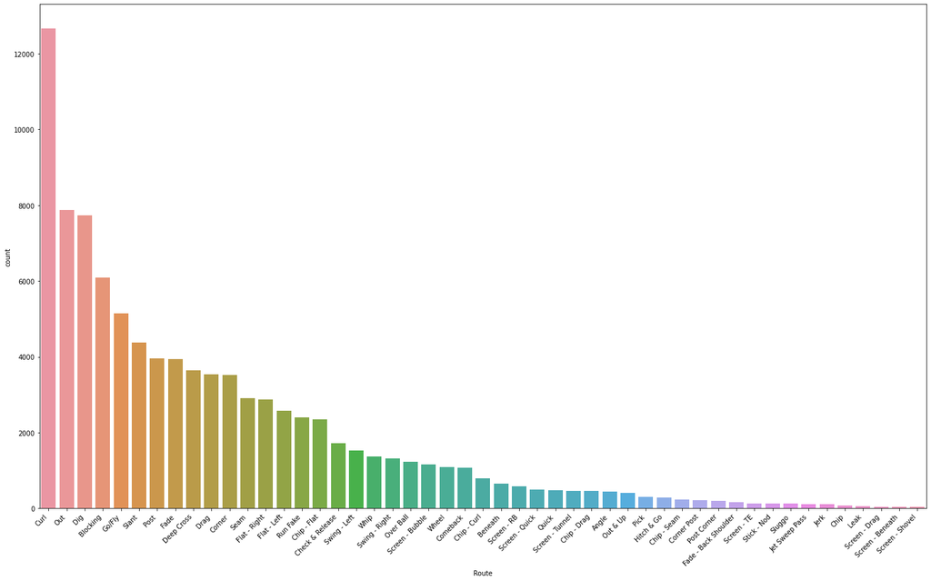

```python
# change the size of the plot
f, ax = plt.subplots(figsize = (24,14))
# create countplot for each route type
chart = sns.countplot(x = "Route", data = player_positions, order = player_positions['Route'].value_counts().index)
# rotate the x-axis labels to be readable
chart.set_xticklabels(chart.get_xticklabels(),rotation = 45, horizontalalignment = 'right')
plt.show()
```

Now we can recreate the same initial plot with the new route types and we see that there are only 15 unique route types and the distribution is slightly more even.

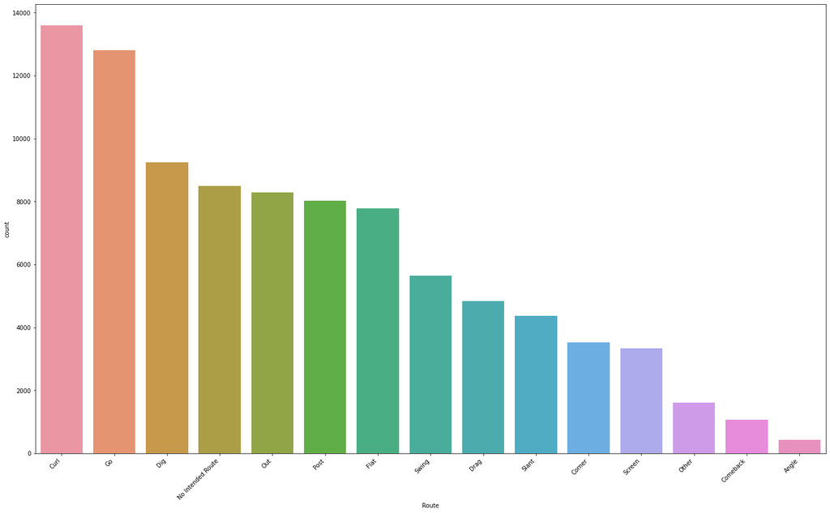

```python
# change the size of the plot
f, ax = plt.subplots(figsize = (24,14))
# create countplot for each route type
chart = sns.countplot(x = "Route", data = valid_routes, order = valid_routes['Route'].value_counts().index)
# rotate the x-axis labels to be readable
chart.set_xticklabels(chart.get_xticklabels(),rotation = 45, horizontalalignment = 'right')
plt.show()
```

Now that we have our final data set ready, we can get deeper into the exploratory data analysis. We started by building a correlation matrix of all of the numeric variables, not including the counts for the individual route types or the drop types.

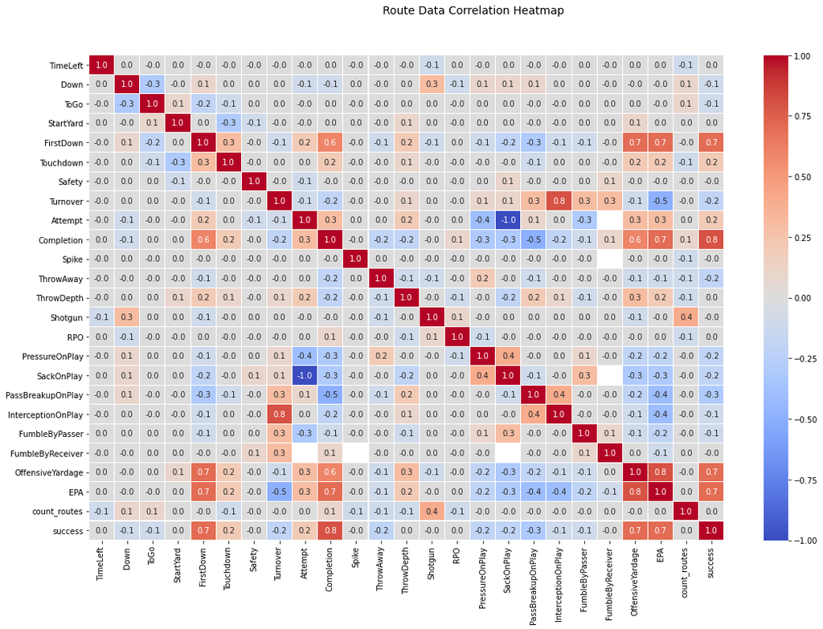

```python
# isolate all of the numeric variables
numeric_variables = route_combo[['TimeLeft', 'Down', 'ToGo', 'StartYard', 'FirstDown', 'Touchdown', 'Safety', 'Turnover', 'Attempt', 'Completion', 'Spike',
                                 'ThrowAway', 'ThrowDepth', 'Shotgun', 'RPO', 'PressureOnPlay', 'SackOnPlay', 'PassBreakupOnPlay', 'InterceptionOnPlay',
                                 'FumbleByPasser', 'FumbleByReceiver', 'OffensiveYardage', 'EPA', 'count_routes', 'success']]

# change the size of the plot
f, ax = plt.subplots(figsize = (18,11))
# calculate the correlations
corr = numeric_variables.corr()
# create a heatmap of the correlation plot
corrplot = sns.heatmap(round(corr, 1), annot=True, ax=ax, cmap="coolwarm", fmt='.1f', linewidths=.03)
f.subplots_adjust(top=0.9)
# change the subtitle
t= f.suptitle('Route Data Correlation Heatmap', fontsize=14)
```

The chart below shows the distribution of Dropback Types by whether a play was a success or not. We see that there is a relative consistent distribution between classes with successes having less than not. The one exception being Trick and Spike which don't have the same distributions but also don't make up as many of the plays.

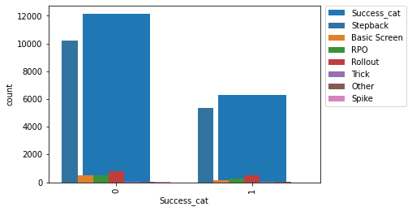

```python
route_combo['Success_cat'].value_counts().plot(kind='bar')
sns.countplot(x="Success_cat", hue="DropType", data = route_combo)
plt.legend(bbox_to_anchor=(1.02, 1), loc='upper left', borderaxespad=0)
```

```python
route_combo.info()
```

```
<class 'pandas.core.frame.DataFrame'>
Int64Index: 18423 entries, 0 to 18422
Data columns (total 61 columns):
 #   Column              Non-Null Count  Dtype
---  ------              --------------  -----
 0   GameID_x            18423 non-null  int64
 1   EventID_x           18423 non-null  int64
 2   Season              18423 non-null  int64
 3   Week                18423 non-null  int64
 4   OffensiveTeam       18423 non-null  object
 5   DefensiveTeam       18423 non-null  object
 6   OffTeamScoreBefore  18423 non-null  int64
 7   DefTeamScoreBefore  18423 non-null  int64
 8   Quarter             18423 non-null  int64
 9   TimeLeft            18423 non-null  int64
```

[output cut: 53 more lines]

Some class balancing will be needed since the 0 class (not successful) is significantly larger than the success class. There are also imbalance in the Dropback Type and thus some balancing may be needed for that.

# 3. Machine Learning

## Expected Success Model with Gradient Boosting

One machine learning technique that we will utilize is the implementation of a Gradient Boosted logistic regression model. We built this model in order to create an "Expected Success" metric. With this, we can calculate the success rate of various route combinations and then calculate the expected success rate of those same route combinations. The difference between these two success rates will be "Success Rate Over Expected," which will be our primary method of answering research question number one.

The first step in building this model is to isolate the specific variables that we want to use. There are some variables (PlayDesc, GameID, PlayID, etc.) that are purely descriptive and so we can immediately eliminate them. Also, in order to make our data readable, we must remove observations in which an NA value exists.

```python
model_data = route_combo.drop(['GameID_x', 'GameID_y', 'EventID_x', 'EventID_y', 'Season', 'Week', 'PlayDesc', 'OffensiveTeam', 'DefensiveTeam', 'OffTeamScoreBefore', 'DefTeamScoreBefore',
                               'Quarter', 'TimeLeft', 'EventType', 'SideOfField', 'StartYard', 'KEY', 'FumbleByRusher', 'DropType', 'EPA'], axis=1)

model_data = model_data.dropna()
```

In order to build the Expected Success model, we used Lasso to perform feature selection before creating the actual gradient boosted model.

```python
from sklearn.linear_model import LogisticRegressionCV, LassoCV
from sklearn.model_selection import cross_val_score, RepeatedKFold
from sklearn.preprocessing import StandardScaler
```

```python
cols = model_data.columns.tolist()
to_remove = cols[22:37] + [cols[14]] + [cols[38]]
X = model_data.loc[:, ~model_data.columns.isin(to_remove)]
y = model_data['success']
model_features = list(X.columns.values)
```

```python
# normalize the data
ss = StandardScaler()
ss.fit(X)
X = ss.transform(X)
```

```python
# initialize the logistic model using cross validated lasso
log_model = LogisticRegressionCV(cv = 10, penalty='l1', solver = 'liblinear')
# fit the model
log_model.fit(X, y)
```

```
LogisticRegressionCV(Cs=10, class_weight=None, cv=10, dual=False,
                     fit_intercept=True, intercept_scaling=1.0, l1_ratios=None,
                     max_iter=100, multi_class='auto', n_jobs=None,
                     penalty='l1', random_state=None, refit=True, scoring=None,
                     solver='liblinear', tol=0.0001, verbose=0)
```

```python
coefficients = log_model.coef_.tolist()[0]
print("Logistic Lasso Regression Coefficient Results:\n")
print('{:20} {:10}'.format("Model Feature", 'Beta Value'))
for i in range(0, len(coefficients)):
    print('{:20} {:3.2}'.format(str(model_features[i]+":"), coefficients[i]))
```

```
Logistic Lasso Regression Coefficient Results:

Model Feature        Beta Value
Down:                -1.1
ToGo:                -0.87
Hash:                0.0
FirstDown:           0.18
Touchdown:           0.56
Safety:              0.0
Turnover:            -2.3
Attempt:             0.0
Completion:          0.88
Spike:               0.0
ThrowAway:           0.0
ThrowDepth:          0.0
Shotgun:             0.0
RPO:                 0.0
PressureOnPlay:      0.0
SackOnPlay:          0.0
PassBreakupOnPlay:   0.0
InterceptionOnPlay:  0.0
FumbleByPasser:      0.0
FumbleByReceiver:    -0.052
OffensiveYardage:    7.8
count_routes:        0.0
Yardline:            -0.054
Success_cat:         1.3
```

Based on the results of the lasso feature selection, we will use the following features in our gradient boosted model:

- Down
- ToGo
- FirstDown
- Touchdown
- Turnover
- Completion
- FumbleByReceiver
- OffensiveYardage
- Yardline

```python
from sklearn.ensemble import GradientBoostingClassifier
```

```python
# need to remove columns that won't be used in the model
cols = model_data.columns.tolist()
to_remove = cols[22:39] + cols[9:20] + [cols[7]] + [cols[2]] + [cols[5]]
# isolate the X variables
X = model_data.loc[:, ~model_data.columns.isin(to_remove)]
# isolate the y variable
y = model_data['success']
# create a list of the model features
model_features = list(X.columns.values)
```

```python
# initiate GB model
gb_model = GradientBoostingClassifier(loss = 'exponential')

# fit the model
gb_model.fit(X, y)

# predict the y values using probabilities of success
y_pred = gb_model.predict_proba(X)
```

Now that we have all of the data needed to evaluate the route combinations, we can combine them into one dataframe. We will then use this dataframe to answer our first research question in the following section.

```python
# isolate the expected success based on the model predictions
xp_success = pd.DataFrame(y_pred[:,1])
xp_success = xp_success.reset_index()

# isolate each of the routes
routes = model_data.iloc[:, 22:37]
routes = routes.reset_index()

# isolate the original success metric for each play
orig_success = model_data.iloc[:, 38]
orig_success = orig_success.reset_index()

# isolate the coverage scheme for each play
coverage = model_data.iloc[:, 14]
coverage = coverage.reset_index()

# combine all of those variables into one dataframe
expected_success_df = pd.concat([routes, coverage, orig_success, xp_success], axis = 1).rename(columns = {0:'xp_success'}).drop('index', axis = 1)
```

## Success based on Dropback Type

We are using a decision tree, a logistic regression, and SVC model for the classification route of success. By looking at node splits and coefficients, we can see if any of the dropback types provide significance for determining if a play will be successful or not.

Based on the data exploration, we include balanced as a class weight parameter since our classes are clearly unbalanced.

We created a function to aid in evaluating the models. This function provides the confusion matrix and other key model stats for classification models

```python
def eval_model(pred, actual):
    '''
    Input: Model Predictions, Actual Values
    Output: Classification Metrics based on inputs

    Takes list of predictions and actuals to compute basic performance stats of a model
    '''
    conf_matrix = metrics.confusion_matrix(y_true = actual, y_pred = pred)

    #Recall
    recall = metrics.recall_score(y_true = actual, y_pred = pred)

    #Specificity
    specificity = conf_matrix[1][1] / (conf_matrix[0][1] + conf_matrix[1][1])

    #Precsion
    precision = metrics.precision_score(y_true = actual, y_pred = pred)


    #F1
    f1 = metrics.f1_score(y_true = actual, y_pred = pred)

    # Balanced Accuracy
    balanced = balanced_accuracy_score(actual, pred)

    return conf_matrix, recall, specificity, precision, balanced, f1
```

We split the data into testing, validation, and training data. and created dummy variables for the categorical variables.

```python
# Drop back impact on Success (First Down / TD)
#Trim columns
y_dropback = route_combo.Success_cat
X_dropback = route_combo[['Down','ToGo','CoverageScheme','PressureOnPlay','count_routes','Yardline','DropType']]
X_dropback = pd.get_dummies(X_dropback,prefix=['CoverageScheme', 'DropType'])
X_dropback.drop('DropType_Spike', axis=1)

#Split into training, testing
X_dropback_train, X_dropback_test, y_dropback_train, y_dropback_test = train_test_split(X_dropback, y_dropback, test_size=0.10, random_state=555)
X_dropback_train, X_dropback_val, y_dropback_train, y_dropback_val = train_test_split(X_dropback_train, y_dropback_train, test_size=0.30, random_state=555)
```

The first model we looked at was the decision tree. This model had a few parameters we looked at for a grid search to find the best. We looked for the max depth, minimum sample split, and the class weight to see if the data performed better when balanced.

```python
params_dt = dict(
    min_samples_split = [10, 50, 100, 200, 300, 400, 500],
    max_depth = [5, 10, 20, 25, 30, 40,None],
    class_weight = ["balanced",None]
)
dt = DecisionTreeClassifier()

gs_dt = GridSearchCV(estimator=dt, param_grid=params_dt, scoring='f1', n_jobs=-1 )

gs_dt.fit(X_dropback_train, y_dropback_train)

gs_dt_pred_train = gs_dt.predict(X_dropback_train)
gs_dt_pred_val = gs_dt.predict(X_dropback_val)

cm_dt, recall_dt, spec_dt, prec_dt, bal_dt, f1_dt = eval_model(gs_dt_pred_val, y_dropback_val)
print(gs_dt.best_params_)

dt_best = DecisionTreeClassifier(**gs_dt.best_params_)
dt_text = dt_best.fit(X_dropback_train, y_dropback_train)
text_representation = tree.export_text(dt_text, feature_names = list(X_dropback_train.columns.values))
print(text_representation)
```

```
{'class_weight': 'balanced', 'max_depth': 5, 'min_samples_split': 500}
|--- ToGo <= 6.50
|   |--- PressureOnPlay <= 0.50
|   |   |--- ToGo <= 4.50
|   |   |   |--- Yardline <= 15.50
|   |   |   |   |--- class: 1
|   |   |   |--- Yardline >  15.50
|   |   |   |   |--- CoverageScheme_Combination <= 0.50
|   |   |   |   |   |--- class: 1
|   |   |   |   |--- CoverageScheme_Combination >  0.50
|   |   |   |   |   |--- class: 0
|   |   |--- ToGo >  4.50
|   |   |   |--- CoverageScheme_Cover 6 <= 0.50
|   |   |   |   |--- Yardline <= 42.50
|   |   |   |   |   |--- class: 1
|   |   |   |   |--- Yardline >  42.50
|   |   |   |   |   |--- class: 1
|   |   |   |--- CoverageScheme_Cover 6 >  0.50
|   |   |   |   |--- class: 0
|   |--- PressureOnPlay >  0.50
|   |   |--- ToGo <= 3.50
|   |   |   |--- class: 1
|   |   |--- ToGo >  3.50
|   |   |   |--- Yardline <= 26.50
|   |   |   |   |--- class: 0
|   |   |   |--- Yardline >  26.50
|   |   |   |   |--- class: 0
|--- ToGo >  6.50
|   |--- PressureOnPlay <= 0.50
|   |   |--- ToGo <= 12.50
|   |   |   |--- CoverageScheme_Screen <= 0.50
|   |   |   |   |--- ToGo <= 8.50
|   |   |   |   |   |--- class: 1
|   |   |   |   |--- ToGo >  8.50
|   |   |   |   |   |--- class: 1
|   |   |   |--- CoverageScheme_Screen >  0.50
|   |   |   |   |--- Down <= 1.50
|   |   |   |   |   |--- class: 0
|   |   |   |   |--- Down >  1.50
|   |   |   |   |   |--- class: 0
|   |   |--- ToGo >  12.50
|   |   |   |--- ToGo <= 16.50
|   |   |   |   |--- class: 0
|   |   |   |--- ToGo >  16.50
|   |   |   |   |--- class: 0
|   |--- PressureOnPlay >  0.50
|   |   |--- ToGo <= 11.50
|   |   |   |--- Yardline <= 15.50
|   |   |   |   |--- class: 0
|   |   |   |--- Yardline >  15.50
|   |   |   |   |--- Down <= 3.50
|   |   |   |   |   |--- class: 0
|   |   |   |   |--- Down >  3.50
|   |   |   |   |   |--- class: 0
|   |   |--- ToGo >  11.50
|   |   |   |--- class: 0
```

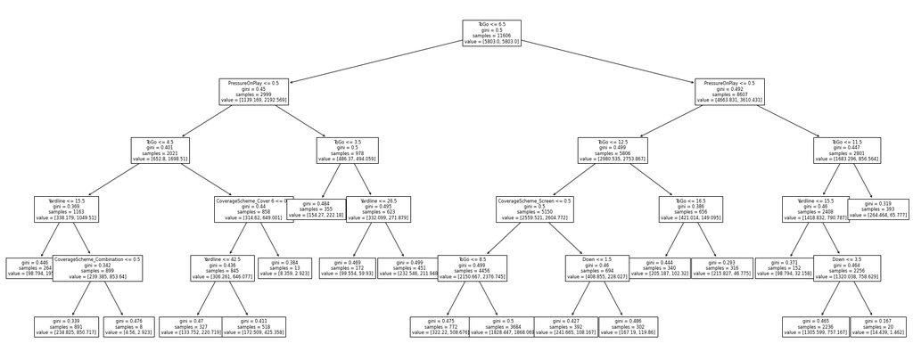

```python
#plot tree
plt.figure(figsize=(30,12))
tree.plot_tree(dt_text,feature_names = list(X_dropback_train.columns.values),fontsize=8)
plt.show()
```

```
<sklearn.metrics._plot.confusion_matrix.ConfusionMatrixDisplay at 0x7f6d99313150>
```

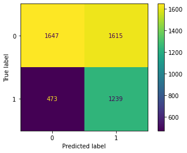

```python
disp = ConfusionMatrixDisplay(cm_dt,display_labels=[0,1])
disp.plot(values_format='g')
```

The initial decision tree showed massive overfitting but adding in a constraint for max depth improved that. When looking at each play as a whole, the actual dropback type didn't show significance enough to cause a split. Other play attributes such as yards to go, pressure, and coverage made a bigger difference.

```python
#Dropback Logistic Regression

params_log = dict(
    C = [1, 1.5, 2],
    class_weight = ["balanced",None]
)
log = LogisticRegression(max_iter=1000)

gs_log = GridSearchCV(estimator=log, param_grid=params_log, scoring='f1', n_jobs=-1 )

gs_log.fit(X_dropback_train, y_dropback_train)

gs_log_pred_train = gs_log.predict(X_dropback_train)
gs_log_pred_val = gs_log.predict(X_dropback_val)

cm_log, recall_log, spec_log, prec_log, bal_log, f1_log = eval_model(gs_log_pred_val, y_dropback_val)
print(gs_log.best_params_)

log_best = LogisticRegression(**gs_log.best_params_,max_iter=1000)
log_fit = log_best.fit(X_dropback_train, y_dropback_train)
log_cof = log_fit.coef_.tolist()[0]
names = list(X_dropback.columns)
summ = [list(a) for a in zip(log_cof, names)]
summ
```

```
{'C': 1.5, 'class_weight': 'balanced'}
```

```
[[0.0003489685562781995, 'Down'],
 [-0.15261267355290997, 'ToGo'],
 [-0.7531506963902115, 'PressureOnPlay'],
 [-0.06577308310480148, 'count_routes'],
 [0.003734830140648123, 'Yardline'],
 [-0.11023979735741093, 'CoverageScheme_Combination'],
 [-0.0023388535475972086, 'CoverageScheme_Cover 0'],
 [0.053979293528306646, 'CoverageScheme_Cover 1'],
 [0.13819913673810852, 'CoverageScheme_Cover 2'],
 [0.23046404432342893, 'CoverageScheme_Cover 3'],
 [0.05128753490718293, 'CoverageScheme_Cover 4'],
 [0.13918684266678805, 'CoverageScheme_Cover 6'],
 [-0.02481884982182769, 'CoverageScheme_Man Cover 2'],
 [0.7455256630365896, 'CoverageScheme_Other'],
 [0.16388312877968797, 'CoverageScheme_Prevent'],
 [-0.4094025313666408, 'CoverageScheme_Screen'],
 [-0.20921854062057657, 'CoverageScheme_Spike'],
 [0.3727762366987034, 'CoverageScheme_Tampa 2'],
 [0.18389657205821053, 'DropType_Basic Screen'],
 [0.024781019633048552, 'DropType_Other'],
 [-0.049644495750288155, 'DropType_RPO'],
 [0.03024619130876585, 'DropType_Rollout'],
 [-0.20921854062057657, 'DropType_Spike'],
 [0.0795731664884687, 'DropType_Stepback'],
 [1.0796493948467247, 'DropType_Trick']]
```

```
<sklearn.metrics._plot.confusion_matrix.ConfusionMatrixDisplay at 0x7f6d98b67950>
```

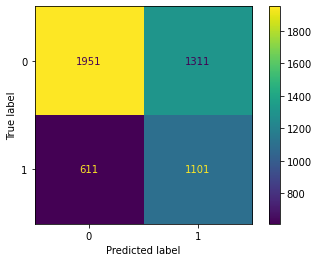

```python
disp = ConfusionMatrixDisplay(cm_log,display_labels=[0,1])
disp.plot(values_format='g')
```

Looking at the coefficients from the logistic regression, trick plays seem to be extremely successful. This is probably due to the lower sample size and how trick plays are designed to pick up a first or a td in tight situations. On thing to note is that cover schemes seemed to perform worse from the defensive perspective. For pass plays, this makes sense because there can be holes in zones which lead to larger gains and therefore first downs.

Other things such as down and ToGo make sense with traditional thinking as more yards make it harder to get the first down and the downs can force the offensive to play more aggressively which typically plays into the defense's hand.

```python
#SVC Model for Dropback Type Classification of Success
svc = SVC(kernel ='rbf')
params_SVC = {
     'gamma': [.01],
     'C': [10],
    "class_weight" : ["balanced"]
 }
# Best model was C: 10, class_weight: balanced, gamm: .01
#To run full parameter test, uncomment the parameters below (Takes longer to run)

#params_SVC = {
#     'gamma': [.01,.1,1],
#     'C': [0.01, .1, 1, 10],
#    "class_weight" : ["balanced",None]


gs_svc = GridSearchCV(estimator=svc, param_grid=params_SVC, scoring='f1', n_jobs=-1 )
gs_svc.fit(X_dropback_train, y_dropback_train)

gs_svc_pred_train = gs_svc.predict(X_dropback_train)
gs_svc_pred_val = gs_svc.predict(X_dropback_val)

cm_svc, recall_svc, spec_svc, prec_svc, bal_svc, f1_svc = eval_model(gs_svc_pred_val, y_dropback_val)
gs_svc.best_params_
```

```
{'C': 10, 'class_weight': 'balanced', 'gamma': 0.01}
```

```
<sklearn.metrics._plot.confusion_matrix.ConfusionMatrixDisplay at 0x7f6d9806f210>
```

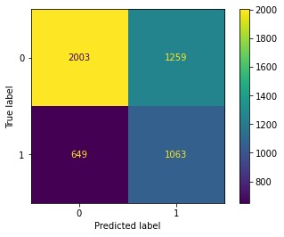

```python
disp = ConfusionMatrixDisplay(cm_svc,display_labels=[0,1])
disp.plot(values_format='g')
```

```python
#Compare Results of each model
d = {"SVC": [recall_svc, spec_svc, prec_svc, bal_svc, f1_svc],
    "Decision Tree": [recall_dt, spec_dt, prec_dt, bal_dt, f1_dt],
    "Logistic Regression": [recall_log, spec_log, prec_log, bal_log, f1_log]
}

print("{:<20} {:<8} {:<11} {:<9} {:<17} {:<8}".format('Model','Recall','Specificity','Precision', 'Balanced Accuracy', 'F1'))
for model, v in d.items():
    recall, spec, prec, bal, f1 = v
    print("{:<20} {:<8.3f} {:<11.3f} {:<9.3f} {:<17.3f} {:.3f}".format(model, recall, spec, prec, bal, f1))
```

```
Model                Recall   Specificity Precision Balanced Accuracy F1
SVC                  0.621    0.458       0.458     0.617             0.527
Decision Tree        0.724    0.434       0.434     0.614             0.543
Logistic Regression  0.643    0.456       0.456     0.621             0.534
```

```python
#Testing Results
testing_pred = dt_text.predict(X_dropback_test)
cm_dt_test, recall_dt_test, spec_dt_test, prec_dt_test, bal_dt_test, f1_dt_test = eval_model(testing_pred, y_dropback_test)
print("{:<20} {:<8} {:<11} {:<9} {:<17} {:<8}".format('Model','Recall','Specificity','Precision', 'Balanced Accuracy', 'F1'))
print("{:<20} {:<8.3f} {:<11.3f} {:<9.3f} {:<17.3f} {:.3f}".format('Decision Tree Test', recall_dt_test, spec_dt_test, prec_dt_test, bal_dt_test, f1_dt_test))
```

```
Model                Recall   Specificity Precision Balanced Accuracy F1
Decision Tree Test   0.738    0.428       0.428     0.618             0.542
```

```
<sklearn.metrics._plot.confusion_matrix.ConfusionMatrixDisplay at 0x7f6d97fc0250>
```

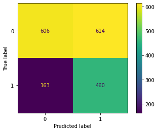

```python
#Testing Matrix
disp = ConfusionMatrixDisplay(cm_dt_test,display_labels=[0,1])
disp.plot(values_format='g')
```

Looking at the best parameters from each, balancing the classes was the correct choice in all 3 model choices. This matches the hypothesis from the data exploration and improves overall accuracy. Balancing the classes significantly improves the recall (increase of .20+) which helps us answer which is the better predictor for success.

Overall the models are roughly the same however the Decision Tree has the better Recall value which helps us predict the Successes better. From that model (and the logistic coefficients), we see that Dropback types are not significant predictors of success.

## Defensive success based on coverage schemes

A logistic regression model and SVC models were used to identify the success rate of coverage schemes against different types of routes and route combinations. Also, the model will be able to identify and predict the optimal coverage scheme based on the route combinations. For this learning model, we will be reconstructing the target variable to focus on defensive stoppage and success. By doing so, we inverted the success target from our expected success model.

We also dropped additional variables that might interfere with the integrity of the model or indicate a successful stoppage by the defense (i.e., Fumble, Turnover, Interception, EPA, Offensive Yardage, etc.). For example, EPA is a formula that calculated the play's expected point added. If the play has a positive EPA, it is more likely to indicate the play was a success and the offensive strategy overbear the defense. These variables indirectly indicated the outcome of the play, which as a result, the model can directly predict the target without examining the route combinations.

```python
#logistic regression model
#create a new dataframe for the model
defenseDF = route_combo
defenseDF = defenseDF.drop(['GameID_x', 'EventID_x', 'Season', 'Week', 'OffensiveTeam', 'DefensiveTeam', 'SideOfField', 'OffTeamScoreBefore', 'DefTeamScoreBefore', 'Quarter',
                            'TimeLeft', 'EventType', 'FirstDown', 'Touchdown', 'Safety', 'Turnover', 'Attempt', 'Completion', 'Spike', 'ThrowAway', 'ThrowDepth', 'PressureOnPlay',
                            'SackOnPlay', 'PassBreakupOnPlay', 'InterceptionOnPlay', 'FumbleByPasser', 'FumbleByRusher', 'FumbleByReceiver', 'PlayDesc', 'KEY', 'GameID_y',
                            'EventID_y', 'EPA', 'OffensiveYardage', 'Yardline'], axis = 1)

#remove target variables from the new dataframe
catFeats = ['DropType', 'CoverageScheme']
defenseDF = pd.get_dummies(defenseDF, columns = catFeats)
```

```python
#invert success to reflect defensive success
defenseDF['defensive_success'] = defenseDF['success'].replace({0:1, 1:0})
defenseDF.dropna()

#logistic regression target variable
y = defenseDF['defensive_success']
defenseDF = defenseDF.drop(['defensive_success', 'success', 'Success_cat'], axis = 1)
```

```python
from sklearn.model_selection import train_test_split
from sklearn import metrics
from sklearn.metrics import confusion_matrix


X_train, X_test, y_train, y_test = train_test_split(defenseDF, y, stratify=y, random_state = 0, test_size= 0.25)
```

```python
from sklearn.linear_model import LogisticRegressionCV
logCLF = LogisticRegressionCV(cv = 10, random_state = 0, max_iter = 10000, solver='lbfgs')
logCLF.fit(X_train, y_train)
log_pred = logCLF.predict(X_train)
```

```python
metrics.accuracy_score(y_true = y_train, y_pred = log_pred)
```

```
0.5726279221249185
```

```python
log_pred = logCLF.predict(X_test)
metrics.accuracy_score(y_true = y_test, y_pred = log_pred)
```

```
0.5618758141554494
```

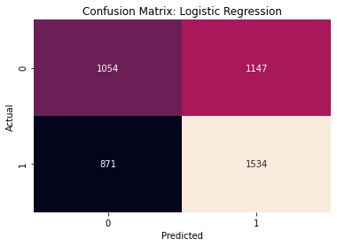

```python
matrix = confusion_matrix(y_test, log_pred)

sns.heatmap(matrix, annot=True, square=False, fmt='', cbar=False)
plt.title('Confusion Matrix: Logistic Regression')
plt.ylabel('Actual')
plt.xlabel('Predicted')
plt.show()
```

The training and testing model result indicated that the model's prediction is slightly better than a coin flip with a .57 on the training data and 0.56 on the testing data. However, the result can be used to predict the success defense's probability and utilize it to find out the popular coverage schemes and the chance of success.

The SVC model will be focused on predicting the optimal coverage scheme for a combination of routes. The data will be filtered only to contain plays with defensive success. The target will be shifted from binary success and not success to type of coverage schemes.

```python
#SVC Model
#filter only select data with successful stoppage
svcData = route_combo[route_combo["success"] == 0]

#filter out unconventional coverage schemes
svcData = svcData[svcData["CoverageScheme"] != 'Other']
svcData = svcData[svcData["CoverageScheme"] != 'Spike']

#combination cause complication
svcData = svcData[svcData["CoverageScheme"] != 'Combination']
```

```python
svcData = svcData.drop(['GameID_x', 'EventID_x', 'Season', 'Week', 'OffensiveTeam', 'DefensiveTeam', 'SideOfField', 'OffTeamScoreBefore', 'DefTeamScoreBefore', 'Quarter',
                        'TimeLeft', 'EventType', 'FirstDown', 'Touchdown', 'Safety', 'Turnover', 'Attempt', 'Completion', 'Spike', 'ThrowAway', 'ThrowDepth', 'PressureOnPlay',
                        'SackOnPlay', 'PassBreakupOnPlay', 'InterceptionOnPlay', 'FumbleByPasser', 'FumbleByRusher', 'FumbleByReceiver', 'PlayDesc', 'KEY', 'GameID_y', 'EventID_y',
                        'EPA', 'OffensiveYardage', 'Yardline', 'success', 'Success_cat'], axis = 1)
svcData.dropna()
```

|  | Down | ToGo | StartYard | Hash | Shotgun | DropType | RPO | CoverageScheme | Angle | Comeback | Corner | Curl | Dig | Drag | Flat | Go | No Intended Route | Other | Out | Post | Screen | Slant | Swing | count_routes |
| --- | --- | --- | --- | --- | --- | --- | --- | --- | --- | --- | --- | --- | --- | --- | --- | --- | --- | --- | --- | --- | --- | --- | --- | --- |
| 0 | 2 | 5 | 30 | 3 | 1 | Stepback | 0 | Cover 1 | 0 | 0 | 0 | 2 | 0 | 0 | 0 | 2 | 0 | 0 | 1 | 0 | 0 | 0 | 0 | 5 |
| 1 | 3 | 10 | 25 | 3 | 1 | Stepback | 0 | Cover 2 | 0 | 0 | 0 | 1 | 1 | 0 | 0 | 1 | 0 | 0 | 0 | 0 | 0 | 0 | 1 | 4 |
| 5 | 2 | 10 | 36 | 3 | 1 | Stepback | 0 | Cover 1 | 0 | 0 | 0 | 0 | 1 | 0 | 1 | 2 | 0 | 0 | 0 | 1 | 0 | 0 | 0 | 5 |
| 6 | 3 | 18 | 44 | 2 | 1 | Stepback | 0 | Cover 3 | 0 | 0 | 0 | 1 | 1 | 0 | 1 | 0 | 0 | 0 | 0 | 1 | 0 | 0 | 0 | 4 |
| 16 | 1 | 8 | 8 | 2 | 1 | RPO | 1 | Cover 1 | 0 | 0 | 0 | 0 | 0 | 1 | 0 | 1 | 3 | 0 | 0 | 0 | 0 | 0 | 0 | 5 |
| ... | ... | ... | ... | ... | ... | ... | ... | ... | ... | ... | ... | ... | ... | ... | ... | ... | ... | ... | ... | ... | ... | ... | ... | ... |
| 18409 | 2 | 4 | 4 | 2 | 0 | Stepback | 0 | Cover 4 | 0 | 0 | 0 | 1 | 0 | 0 | 1 | 0 | 0 | 0 | 1 | 0 | 0 | 0 | 0 | 3 |
| 18410 | 3 | 4 | 4 | 2 | 1 | Stepback | 0 | Cover 0 | 0 | 0 | 1 | 0 | 0 | 1 | 1 | 1 | 0 | 0 | 0 | 0 | 0 | 1 | 0 | 5 |
| 18412 | 1 | 10 | 25 | 1 | 1 | Stepback | 0 | Cover 2 | 0 | 0 | 0 | 1 | 0 | 0 | 2 | 1 | 0 | 0 | 1 | 0 | 0 | 0 | 0 | 5 |
| 18413 | 2 | 10 | 25 | 1 | 1 | Stepback | 0 | Cover 4 | 0 | 0 | 0 | 0 | 3 | 0 | 0 | 2 | 0 | 0 | 0 | 0 | 0 | 0 | 0 | 5 |
| 18418 | 1 | 10 | 25 | 3 | 1 | Stepback | 0 | Cover 3 | 0 | 0 | 0 | 0 | 0 | 0 | 1 | 0 | 0 | 1 | 0 | 0 | 0 | 3 | 0 | 5 |

9558 rows × 24 columns

```python
#factorize CoverageScheme as target
y = svcData['CoverageScheme']
svc_y_fact = y.factorize()
y = svc_y_fact[0]
```

```python
#class distribution
yClass = pd.DataFrame(y, columns =['class'])
yClass
yClass.groupby(['class']).size()
```

```
class
0    2417
1     825
2    2556
3     293
4     238
5     484
6    1502
7    1011
8      80
9     152
dtype: int64
```

After the coverage schemes had been factorized, the two most common cover schemes are Cover 1 and Cover 3. While Cover 6 and Screen coverage have the third and fourth highest distribution respectively. Two other classes, "Spike" and "Other," were removed from the data. Spike coverage is only deployed when the offensive team needs to spike the ball to stop the play and the game time. "Other" coverage was a non-traditional coverage that does not fit any description of the coverage scheme. Both classes combined did not exceed 100 plays, so it does not impact the model's accuracy.

```python
svcData = svcData.drop(['CoverageScheme'], axis = 1)
svcData = pd.get_dummies(svcData)
```

```python
X_train, X_test, y_train, svc_y_test = train_test_split(svcData, y, test_size=0.25, random_state = 0)
```

```python
#standardize the data
from sklearn.preprocessing import StandardScaler
ss = StandardScaler()
ss.fit(X_train)
X_train = ss.transform(X_train)
X_test = ss.transform(X_test)
```

```python
from sklearn.decomposition import PCA
pca = PCA(n_components=None)

pca.fit(X_train)
X_train_pca = pca.transform(X_train)
X_test_pca = pca.transform(X_test)
```

```python
from sklearn.svm import SVC
from sklearn.model_selection import GridSearchCV

svc = SVC()
svc.fit(X_train_pca, y_train)
svc_pred = svc.predict(X_test_pca)
print('Accuracy Score:', metrics.accuracy_score(svc_y_test, svc_pred), '\n')
print(metrics.classification_report(svc_y_test, svc_pred))
```

```
Accuracy Score: 0.4246861924686193

              precision    recall  f1-score   support

           0       0.38      0.55      0.45       601
           1       0.00      0.00      0.00       208
           2       0.36      0.61      0.45       672
           3       0.00      0.00      0.00        60
           4       0.00      0.00      0.00        55
           5       0.00      0.00      0.00       123
           6       0.28      0.08      0.12       363
           7       0.90      0.97      0.93       254
           8       0.00      0.00      0.00        23
           9       0.00      0.00      0.00        31

    accuracy                           0.42      2390
   macro avg       0.19      0.22      0.20      2390
weighted avg       0.33      0.42      0.36      2390
```

The result indicated the imbalance of classes led to a decrease in accuracy compared to the logistic regression model. Furthermore, the SVC with multi-class was unable to predict classes with a low sample size given the 0 precision and recall on the cover classes.

Most cover is a variation of each other, so in theory, we can concatenate the cover class by its similarity into two cover classes. With that, we can produce a more accurate model given the increased sample size.

```python
#SVC Model - reduced multi-class

#filter only select data with successful stoppage
groupSVC = route_combo[route_combo["success"] == 0]

#filter out unconventional coverage schemes
groupSVC = groupSVC[groupSVC["CoverageScheme"] != 'Other']
groupSVC = groupSVC[groupSVC["CoverageScheme"] != 'Spike']

#combination cause complication
groupSVC = groupSVC[groupSVC["CoverageScheme"] != 'Combination']
```

```python
#new dataframe for reduced multi-class
groupSVC = groupSVC.drop(['GameID_x', 'EventID_x', 'Season', 'Week', 'OffensiveTeam', 'DefensiveTeam', 'SideOfField', 'OffTeamScoreBefore', 'DefTeamScoreBefore', 'Quarter',
                          'TimeLeft', 'EventType', 'FirstDown', 'Touchdown', 'Safety', 'Turnover', 'Attempt', 'Completion', 'Spike', 'ThrowAway', 'ThrowDepth', 'PressureOnPlay',
                          'SackOnPlay', 'PassBreakupOnPlay', 'InterceptionOnPlay', 'FumbleByPasser', 'FumbleByRusher', 'FumbleByReceiver', 'PlayDesc', 'KEY', 'GameID_y',
                          'EventID_y', 'EPA', 'OffensiveYardage', 'Yardline', 'success', 'Success_cat'], axis = 1)
groupSVC.dropna()
```

|  | Down | ToGo | StartYard | Hash | Shotgun | DropType | RPO | CoverageScheme | Angle | Comeback | Corner | Curl | Dig | Drag | Flat | Go | No Intended Route | Other | Out | Post | Screen | Slant | Swing | count_routes |
| --- | --- | --- | --- | --- | --- | --- | --- | --- | --- | --- | --- | --- | --- | --- | --- | --- | --- | --- | --- | --- | --- | --- | --- | --- |
| 0 | 2 | 5 | 30 | 3 | 1 | Stepback | 0 | Cover 1 | 0 | 0 | 0 | 2 | 0 | 0 | 0 | 2 | 0 | 0 | 1 | 0 | 0 | 0 | 0 | 5 |
| 1 | 3 | 10 | 25 | 3 | 1 | Stepback | 0 | Cover 2 | 0 | 0 | 0 | 1 | 1 | 0 | 0 | 1 | 0 | 0 | 0 | 0 | 0 | 0 | 1 | 4 |
| 5 | 2 | 10 | 36 | 3 | 1 | Stepback | 0 | Cover 1 | 0 | 0 | 0 | 0 | 1 | 0 | 1 | 2 | 0 | 0 | 0 | 1 | 0 | 0 | 0 | 5 |
| 6 | 3 | 18 | 44 | 2 | 1 | Stepback | 0 | Cover 3 | 0 | 0 | 0 | 1 | 1 | 0 | 1 | 0 | 0 | 0 | 0 | 1 | 0 | 0 | 0 | 4 |
| 16 | 1 | 8 | 8 | 2 | 1 | RPO | 1 | Cover 1 | 0 | 0 | 0 | 0 | 0 | 1 | 0 | 1 | 3 | 0 | 0 | 0 | 0 | 0 | 0 | 5 |
| ... | ... | ... | ... | ... | ... | ... | ... | ... | ... | ... | ... | ... | ... | ... | ... | ... | ... | ... | ... | ... | ... | ... | ... | ... |
| 18409 | 2 | 4 | 4 | 2 | 0 | Stepback | 0 | Cover 4 | 0 | 0 | 0 | 1 | 0 | 0 | 1 | 0 | 0 | 0 | 1 | 0 | 0 | 0 | 0 | 3 |
| 18410 | 3 | 4 | 4 | 2 | 1 | Stepback | 0 | Cover 0 | 0 | 0 | 1 | 0 | 0 | 1 | 1 | 1 | 0 | 0 | 0 | 0 | 0 | 1 | 0 | 5 |
| 18412 | 1 | 10 | 25 | 1 | 1 | Stepback | 0 | Cover 2 | 0 | 0 | 0 | 1 | 0 | 0 | 2 | 1 | 0 | 0 | 1 | 0 | 0 | 0 | 0 | 5 |
| 18413 | 2 | 10 | 25 | 1 | 1 | Stepback | 0 | Cover 4 | 0 | 0 | 0 | 0 | 3 | 0 | 0 | 2 | 0 | 0 | 0 | 0 | 0 | 0 | 0 | 5 |
| 18418 | 1 | 10 | 25 | 3 | 1 | Stepback | 0 | Cover 3 | 0 | 0 | 0 | 0 | 0 | 0 | 1 | 0 | 0 | 1 | 0 | 0 | 0 | 3 | 0 | 5 |

9558 rows × 24 columns

```python
#convert different cover schemes by cover's similarity
coverage = {'Cover 0' : 'Cover 1',
          'Cover 1' : 'Cover 1',
          'Cover 2' : 'Cover 3',
          'Cover 3' : 'Cover 3',
          'Cover 4' : 'Cover 3',
          'Man Cover 2' : 'Cover 1',
          'Cover 6' : 'Cover 3',
          'Screen' : 'Screen',
          'Prevent' : 'Prevent',
          'Tampa 2' : 'Tampa 2'}


for sub, new in coverage.items():
    groupSVC.loc[groupSVC['CoverageScheme'].str.contains(sub),'CoverageScheme'] = new
```

```python
#factorize CoverageScheme as target
y = groupSVC['CoverageScheme']
reduced_y_fact = y.factorize()
y = reduced_y_fact[0]

#class distribution
yClass = pd.DataFrame(y, columns =['class'])
yClass
yClass.groupby(['class']).size()
```

```
class
0    2710
1    5605
2    1011
3      80
4     152
dtype: int64
```

After combining cover schemes into Cover 1 and Cover 3 by their similarity, the class distribution remains imbalanced as the Cover 3 class contributes half of the class distribution.

```python
groupSVC = groupSVC.drop(['CoverageScheme'], axis = 1)
groupSVC = pd.get_dummies(groupSVC)
X_train, X_test, y_train, reduced_y_test = train_test_split(groupSVC, y, test_size = 0.3, random_state = 0)

#standardize the data
ss = StandardScaler()
ss.fit(X_train)
X_train = ss.transform(X_train)
X_test = ss.transform(X_test)

#PCA
pca = PCA(n_components=None)
pca.fit(X_train)
X_train_pca = pca.transform(X_train)
X_test_pca = pca.transform(X_test)
```

```python
estimator = SVC(kernel ='rbf')
params = dict(
    C = [1, 10, 100, 1000, 2000],
    gamma = [0.0001, 0.001, 0.01, 0.1, 1, 5, 10]
)

svc = GridSearchCV(estimator = estimator, param_grid = params)
svc.fit(X_train_pca, y_train)

best_estimator = svc.best_estimator_
print(svc.best_estimator_)
reduced_pred = best_estimator.predict(X_test_pca)
print('Accuracy Score:', metrics.accuracy_score(reduced_y_test, reduced_pred), '\n')
print(metrics.classification_report(reduced_y_test, reduced_pred))
```

```
SVC(C=10, break_ties=False, cache_size=200, class_weight=None, coef0=0.0,
    decision_function_shape='ovr', degree=3, gamma=0.01, kernel='rbf',
    max_iter=-1, probability=False, random_state=None, shrinking=True,
    tol=0.001, verbose=False)
Accuracy Score: 0.7158298465829847

              precision    recall  f1-score   support

           0       0.65      0.20      0.31       795
           1       0.70      0.94      0.80      1708
           2       0.92      0.94      0.93       299
           3       0.00      0.00      0.00        29
           4       0.00      0.00      0.00        37

    accuracy                           0.72      2868
   macro avg       0.45      0.42      0.41      2868
weighted avg       0.69      0.72      0.66      2868
```

The reduced class SVC performs significantly better with .72 accuracy compared to the SVC multi-class .42. Though the issue remains as Cover 1's recall is lower than the SVC multi-class model. Prevent, and Tampa 2 remains 0 as the model cannot accurately predict the outcome. It is possible that the lack of sample and its coverage specialty that the model cannot determine the route combination which calls for the coverage scheme.

# 4. Research Question Results

## Expected Success Rate Evaluation

Once we had the expected success model built, we could go ahead and measure which route combinations were best. To do this, we created a "Success Rate Over Expected" metric, which takes the difference between the Success Rate (the percent of plays in which a specific route combination was deemed a 'success') and the Expected Success Rate (the average probability of successful plays based on the gradient boosted model).

```python
# create a route combination column for each observation
for index, row in expected_success_df.iterrows():
    temp_str = ''

    angle = row['Angle'] * 'Angle, '
    comeback = row['Comeback'] * 'Comeback, '
    corner = row['Corner'] * 'Corner, '
    curl = row['Curl'] * 'Curl, '
    dig = row['Dig'] * 'Dig, '
    drag = row['Drag'] * 'Drag, '
    flat = row['Flat'] * 'Flat, '
    go = row['Go'] * 'Go, '
    other = row['Other'] * 'Other, '
    out = row['Out'] * 'Out, '
    post = row['Post'] * 'Post, '
    screen = row['Screen'] * 'Screen, '
    slant = row['Slant'] * 'Slant, '
    swing = row['Swing'] * 'Swing, '

    temp_str = str(angle + comeback + corner + curl + dig + drag + flat + go + other + out + post + screen + slant + swing)
    temp_str = temp_str[:-2]
    expected_success_df.at[index, 'route_combo'] = temp_str
```

```python
# get the success rates and expected success rates and the counts of each route combo
success_means = expected_success_df.groupby('route_combo', as_index=False)['success', 'xp_success'].mean()
route_counts = expected_success_df.groupby('route_combo', as_index=False).size()
# join the two dataframes created
sroe_df = pd.concat([success_means, route_counts], axis = 1)
sroe_df = sroe_df.loc[:,~sroe_df.columns.duplicated()]
# rename the columns to be more accurate and convert them to percentages
sroe_df = sroe_df.rename(columns = {"success" : "success_rate", "xp_success" : "exp_success_rate"})
sroe_df['success_rate'] = round(sroe_df['success_rate']*100, 1)
sroe_df['exp_success_rate'] = round(sroe_df['exp_success_rate']*100, 1)
# calculate the success rate over expected (SROE)
sroe_df['sroe'] = sroe_df['success_rate'] - sroe_df['exp_success_rate']

# filter on route combinations with a minimum of 20 plays
sroe_final = sroe_df.loc[sroe_df['size'] >= 20]
sroe_final.sort_values('sroe', ascending = False).head()
```

|  | route_combo | success_rate | exp_success_rate | size | sroe |
| --- | --- | --- | --- | --- | --- |
| 1600 | Curl, Curl, Go, Out, Swing | 65.2 | 56.0 | 23 | 9.2 |
| 1789 | Curl, Dig, Go, Go, Swing | 62.5 | 55.4 | 24 | 7.1 |
| 1982 | Curl, Flat, Go, Go, Out | 46.2 | 39.8 | 26 | 6.4 |
| 2062 | Curl, Go, Go, Go, Post | 50.0 | 43.8 | 30 | 6.2 |
| 3095 | Flat, Go, Out, Slant, Slant | 65.0 | 59.2 | 20 | 5.8 |

Based on this, we see that the best route combination is one of "Curl, Curl, Go, Out, and Swing" as it has a Success Rate Over Expectation (SROE) of 9.2%. The next best combination being "Curl, Dig, Go, Go, Swing" with a SROE of 7.1%. The next step of our evaluation was to see which route combination was best against the different coverage schemes. To do this, we will repeate the code above but add the grouping of the coverage scheme.

```python
success_means = expected_success_df.groupby(['route_combo', 'CoverageScheme'], as_index=False)['success', 'xp_success'].mean()
route_counts = expected_success_df.groupby(['route_combo', 'CoverageScheme'], as_index=False).size()
sroe_df = pd.concat([success_means, route_counts], axis = 1)
sroe_df = sroe_df.loc[:,~sroe_df.columns.duplicated()]
sroe_df = sroe_df.rename(columns = {"success" : "success_rate", "xp_success" : "exp_success_rate"})
sroe_df['success_rate'] = round(sroe_df['success_rate']*100, 1)
sroe_df['exp_success_rate'] = round(sroe_df['exp_success_rate']*100, 1)
sroe_df['sroe'] = sroe_df['success_rate'] - sroe_df['exp_success_rate']

# filter on route combinations with a minimum of 20 plays
sroe_final = sroe_df.loc[sroe_df['size'] >= 20]
sroe_final.sort_values('sroe', ascending = False).head(10)
```

|  | route_combo | CoverageScheme | success_rate | exp_success_rate | size | sroe |
| --- | --- | --- | --- | --- | --- | --- |
| 2255 | Corner, Drag, Post | Cover 3 | 57.1 | 51.8 | 21 | 5.3 |
| 7434 | Go, Go, Go, Go, Screen | Screen | 42.9 | 38.8 | 21 | 4.1 |
| 7374 | Flat, Screen, Slant | Screen | 47.6 | 44.0 | 21 | 3.6 |
| 8001 | Post, Screen | Screen | 42.9 | 39.8 | 21 | 3.1 |
| 8039 | Screen, Slant | Screen | 35.9 | 33.0 | 39 | 2.9 |
| 2655 | Curl, Curl, Curl, Flat, Flat | Cover 3 | 57.1 | 54.3 | 35 | 2.8 |
| 8024 | Screen | Cover 3 | 70.0 | 67.5 | 20 | 2.5 |
| 5079 | Curl, Screen | Screen | 71.4 | 69.4 | 21 | 2.0 |
| 7811 | Go, Screen, Swing | Screen | 27.6 | 26.3 | 29 | 1.3 |
| 8049 | Screen, Swing | Screen | 53.6 | 52.8 | 28 | 0.8 |

Based on these results, it is clear that Cover 3 and Screen are two of the worse defensive coverages as they make up the top ten in SROE allowed. We see that a "Corner, Drag, and Post" route combination specifically against Cover 3 is the most effective route combaination against a Coverage Scheme with an SROE of 5.3%.

## Dropback Success Rates

Continued experiments into models focused on dropback type and success will show if individual types hold any significance for influencing success rate.

```python
from sklearn.linear_model import LogisticRegression

y_dropback = route_combo.Success_cat
X_dropback = route_combo[['Down','ToGo','PressureOnPlay','DropType']]
X_dropback = pd.get_dummies(X_dropback,prefix=['DropType'])
X_dropback.drop('DropType_Spike', axis=1)

#Split into training, testing
X_dropback_train, X_dropback_test, y_dropback_train, y_dropback_test = train_test_split(X_dropback, y_dropback, test_size=0.10, random_state=555)
X_dropback_train, X_dropback_val, y_dropback_train, y_dropback_val = train_test_split(X_dropback_train, y_dropback_train, test_size=0.30, random_state=555)

log = LogisticRegression(max_iter=1000)
log.fit(X_dropback_train, y_dropback_train)

log_dropback_train = log.predict(X_dropback_train)
#Training Accuracy
log_dropback_train_acc = metrics.accuracy_score(y_true = y_dropback_train, y_pred = log_dropback_train)
print("Training Accuracy: {}".format(log_dropback_train_acc))

log_dropback_val = log.predict(X_dropback_val)
#Training Accuracy
log_dropback_val_acc = metrics.accuracy_score(y_true = y_dropback_val, y_pred = log_dropback_val)
print("Validation Accuracy: {}".format(log_dropback_val_acc))

log_cof = log.coef_.tolist()[0]
names = list(X_dropback.columns)
summ = [list(a) for a in zip(log_cof, names)]
summ
```

```
Training Accuracy: 0.6825779769084956
Validation Accuracy: 0.6879774829111379
```

```
[[-0.024430054850137148, 'Down'],
 [-0.1500399659589062, 'ToGo'],
 [-0.7343746641391047, 'PressureOnPlay'],
 [-0.30196823960300223, 'DropType_Basic Screen'],
 [-0.060270060032522874, 'DropType_Other'],
 [-0.1695646265337869, 'DropType_RPO'],
 [0.06242934581697528, 'DropType_Rollout'],
 [-0.5108619453144357, 'DropType_Spike'],
 [0.09433367713252588, 'DropType_Stepback'],
 [1.042884193603287, 'DropType_Trick']]
```

Experimental results for removing defensive schemes from the model shows similar results for Down and ToGo. We see more seperation in the drop back types with the RPO and Screens showing to be worse than the others. An RPO opens up a QB to more pressure as the play takes more time to develop than a standard stepback. Screen plays are also higher risk which makes sense given the pressure on the QB as the play develops and the situations screens are usually called in.

Next steps for this experiment are to find if any of the coefficients are significant and perform statistical anaysis on the success rate of each dropback type to see if they are actually different.

Below is the chi^2 test to see if DropType is a significant predictor or Success

```python
from scipy.stats import chi2_contingency
contigency= pd.crosstab(route_combo['DropType'], route_combo['Success_cat'],normalize='index')
# Chi-square test of independence.
c, p, dof, expected = chi2_contingency(contigency)
# Print the p-value
print(p)
print(dof)
print(c)
```

```
0.9922677319109742
6
0.7927091722634727
```

Based on the p-value, we see that dropback type and the Success (using First Down and TD) are not statistically significant. Individuals may still be significant but further testing is needed.

[output not shown]

## Interception Classification

Another application of machine learning performed on this data is an attempt to classify different factors in terms of whether or not the play would result in an interception. Multiple classification methods were used. Initially an issue of class imbalance was encountered, but through oversampling the imbalance was addressed an overcome.

```python
Int_route_combo = route_combo.copy()
```

```python
cat_feats = ['SideOfField', 'DropType', 'CoverageScheme']
Int_route_combo = pd.get_dummies(Int_route_combo,columns=cat_feats)
```

```python
Int_route_combo['InterceptionOnPlay'].value_counts()
```

```
0.0    18057
1.0      366
Name: InterceptionOnPlay, dtype: int64
```

#### Removal of features

Certain features were removed if they would interfere with the interception variable. Any features that indicated an interception would certainly occur or not occur on a play were removed so that the classification model could predict interceptions based on factors during or before a play was run

```python
Int_route_combo = Int_route_combo.drop(['OffensiveYardage', 'EPA', 'FumbleByPasser', 'Safety', 'Touchdown', 'FirstDown', 'ThrowAway', 'Spike', 'SackOnPlay', 'PassBreakupOnPlay', 'Completion', 'Turnover', 'FumbleByReceiver', 'KEY', 'EventType', 'GameID_x', 'EventID_x', 'Season', 'Week', 'OffensiveTeam', 'DefensiveTeam', 'EventID_y', 'GameID_y', 'PlayDesc', 'FumbleByRusher'], axis = 1)
YesInt = Int_route_combo[route_combo.InterceptionOnPlay == 1]
NoInt = Int_route_combo[route_combo.InterceptionOnPlay == 0]
```

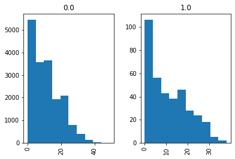

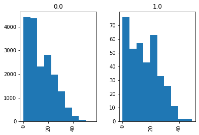

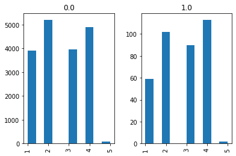

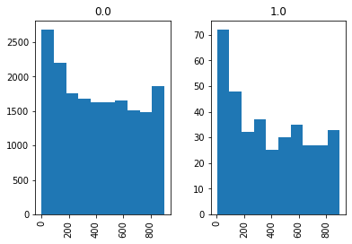

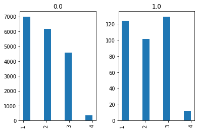

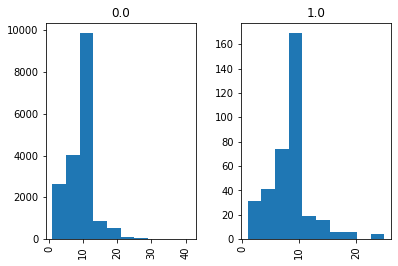

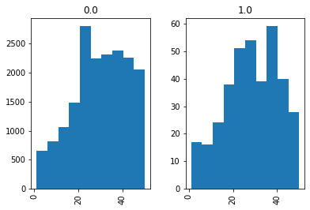

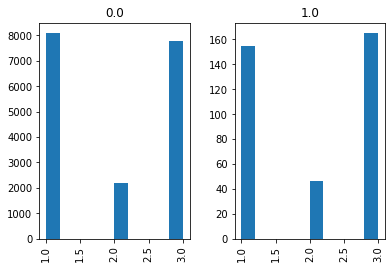

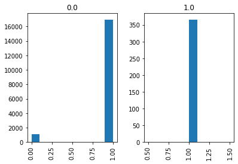

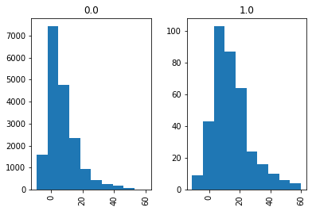

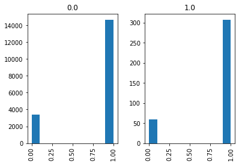

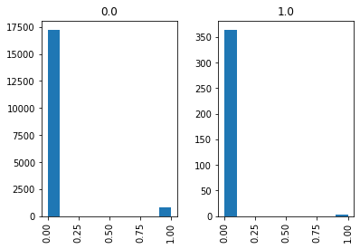

[40 more figures not shown]

```python
for col in Int_route_combo:
    Int_route_combo.hist(column = col, by = 'InterceptionOnPlay')
```

Initial Classification Attempts

```python
from sklearn.tree import DecisionTreeClassifier, plot_tree
from sklearn import metrics
from sklearn.metrics import confusion_matrix
from sklearn.ensemble import RandomForestClassifier
from sklearn.ensemble import AdaBoostClassifier
from sklearn.model_selection import train_test_split
from sklearn.model_selection import GridSearchCV
```

```python
X = Int_route_combo.drop('InterceptionOnPlay',axis=1)
y = Int_route_combo['InterceptionOnPlay']
X_train, X_test, y_train, y_test = train_test_split(X, y, stratify=y, random_state = 55, test_size= 0.25)
```

```python
clf = DecisionTreeClassifier(class_weight = 'balanced')
clf.fit(X_train, y_train)
predTrain = clf.predict(X_train)
accuracyTrain = metrics.accuracy_score(y_true = y_train, y_pred = predTrain)
predTest = clf.predict(X_test)
accuracyTest = metrics.accuracy_score (y_true = y_test, y_pred = predTest)
print('The training accuracy is {}, and the testing accuracy is {}'.format(accuracyTrain, accuracyTest))
```

```
The training accuracy is 1.0, and the testing accuracy is 0.9639600521059488
```

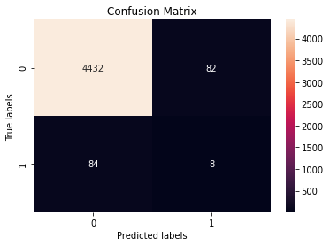

```python
cm = confusion_matrix(y_test, predTest)
ax = plt.subplot()
sns.heatmap(cm, annot=True, fmt='g', ax=ax);  #annot=True to annotate cells, ftm='g' to disable scientific notation

# labels, title and ticks
ax.set_xlabel('Predicted labels');ax.set_ylabel('True labels');
ax.set_title('Confusion Matrix');
```

```python
Recall = sklearn.metrics.recall_score(y_true = y_test, y_pred = predTest)
tn, fp, fn, tp = confusion_matrix(y_true = y_test, y_pred = predTest).ravel()
specificity = tn / (tn+fp)
precision = metrics.precision_score(y_true = y_test, y_pred = predTest)
BalancedAccuracy = metrics.balanced_accuracy_score(y_true = y_test, y_pred = predTest, sample_weight=None, adjusted=False)
F1Score = sklearn.metrics.f1_score(y_true = y_test, y_pred = predTest)
print('Recall: {}, Specificity: {}, Precision: {}, Balanced Accuracy: {}, F1 Score: {}'.format(Recall, specificity, precision, BalancedAccuracy, F1Score))
```

```
Recall: 0.08695652173913043, Specificity: 0.9818342933097032, Precision: 0.08888888888888889, Balanced Accuracy: 0.5343954075244168, F1 Score: 0.0879120879120879
```

```python
columns = Int_route_combo.columns
feat_import = clf.feature_importances_
res = "\n".join("{} {}".format(x, y) for x, y in zip(columns, feat_import))
print(res)
```

```
OffTeamScoreBefore 0.027717889171374906
DefTeamScoreBefore 0.031125064424985915
Quarter 0.00998338428150775
TimeLeft 0.07884012160915241
Down 0.009915452166148865
ToGo 0.01837586628369813
StartYard 0.03888042525570322
Hash 0.009327426806771169
Attempt 0.011385893820352867
ThrowDepth 0.164538168636754
Shotgun 0.005044188700565433
RPO 0.0032518889630449737
PressureOnPlay 0.0034587580750758775
InterceptionOnPlay 0.0026372588708798122
Angle 0.009691990825441978
Comeback 0.009627162626704525
Corner 0.01839022735330166
Curl 0.028115168724673092
Dig 0.012751333783655677
Drag 0.004042433173294688
Flat 0.0153706802113727
Go 0.005662336359018988
No Intended Route 0.008727356331320772
Other 0.017482595859462508
Out 0.0065662078287595195
Post 0.002690699075181388
Screen 0.003139155823408082
Slant 0.009451316572658627
Swing 0.004616273269552868
count_routes 0.31178767565992005
success 0.045972037669295605
Yardline 0.03791649709164598
Success_cat 0.0
SideOfField_Oppo 0.001055491907686347
SideOfField_Own 0.0
DropType_Basic Screen 0.0
DropType_Other 0.0002782197130302351
DropType_RPO 0.0
DropType_Rollout 0.0
DropType_Spike 0.004051240088801332
DropType_Stepback 0.0
DropType_Trick 0.00014425315784787984
CoverageScheme_Combination 0.0015105069891646911
CoverageScheme_Cover 0 0.0025068520656732836
CoverageScheme_Cover 1 0.004590574040922565
CoverageScheme_Cover 2 0.00489686450867441
CoverageScheme_Cover 3 0.0013900571680470518
CoverageScheme_Cover 4 0.0028450418467599
CoverageScheme_Cover 6 0.005318619231149719
CoverageScheme_Man Cover 2 0.0002805879805148589
CoverageScheme_Other 0.0
CoverageScheme_Prevent 0.0
CoverageScheme_Screen 0.0
CoverageScheme_Spike 0.004648755997043749
```

Overall, the accuracy scores are quite high, but this is misleading due to the imbalance of classes. The model performed quite poorly in terms of classifying true positive values properly.

```python
clf = RandomForestClassifier(class_weight ='balanced')
clf.fit(X_train, y_train)
predTrain = clf.predict(X_train)
accuracyTrain = metrics.accuracy_score(y_true = y_train, y_pred = predTrain)
predTest = clf.predict(X_test)
accuracyTest = metrics.accuracy_score (y_true = y_test, y_pred = predTest)
print('The training accuracy is {}, and the testing accuracy is {}'.format(accuracyTrain, accuracyTest))
```

```
The training accuracy is 1.0, and the testing accuracy is 0.9800260529743813
```

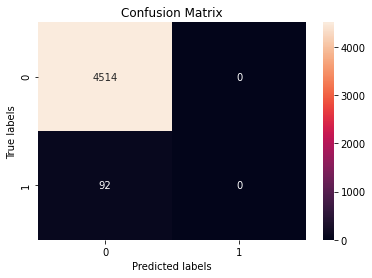

```python
cm = confusion_matrix(y_test, predTest)
ax = plt.subplot()
sns.heatmap(cm, annot=True, fmt='g', ax=ax);  #annot=True to annotate cells, ftm='g' to disable scientific notation

# labels, title and ticks
ax.set_xlabel('Predicted labels');ax.set_ylabel('True labels');
ax.set_title('Confusion Matrix');
```

```python
Recall = sklearn.metrics.recall_score(y_true = y_test, y_pred = predTest)
tn, fp, fn, tp = confusion_matrix(y_true = y_test, y_pred = predTest).ravel()
specificity = tn / (tn+fp)
precision = metrics.precision_score(y_true = y_test, y_pred = predTest)
BalancedAccuracy = metrics.balanced_accuracy_score(y_true = y_test, y_pred = predTest, sample_weight=None, adjusted=False)
F1Score = sklearn.metrics.f1_score(y_true = y_test, y_pred = predTest)
print('Recall: {}, Specificity: {}, Precision: {}, Balanced Accuracy: {}, F1 Score: {}'.format(Recall, specificity, precision, BalancedAccuracy, F1Score))
```

```
Recall: 0.0, Specificity: 1.0, Precision: 0.0, Balanced Accuracy: 0.5, F1 Score: 0.0
```

```python
columns = Int_route_combo.columns
feat_import = clf.feature_importances_
res = "\n".join("{} {}".format(x, y) for x, y in zip(columns, feat_import))
print(res)
```

```
OffTeamScoreBefore 0.0377299724212835
DefTeamScoreBefore 0.03964506346785964
Quarter 0.020941876611490547
TimeLeft 0.05984592547457595
Down 0.018731675068956406
ToGo 0.0303672611399054
StartYard 0.047742945337956234
Hash 0.014217825873293241
Attempt 0.02447580918018822
ThrowDepth 0.13339698794759955
Shotgun 0.005459916857247176
RPO 0.0018600309639950317
PressureOnPlay 0.011452901935662924
InterceptionOnPlay 0.0018753480868941813
Angle 0.004798104574393204
Comeback 0.0073543312000268046
Corner 0.017244354115091294
Curl 0.014346295362903081
Dig 0.0141274316050483
Drag 0.010265655223234848
Flat 0.017901201803157945
Go 0.012411598753349636
No Intended Route 0.006071152514450412
Other 0.014546688891682077
Out 0.0114517237387774
Post 0.009607978345414282
Screen 0.008706643861961816
Slant 0.010088270981621683
Swing 0.014298515106663636
count_routes 0.198302247485682
success 0.048683020456087
Yardline 0.057250436597496575
Success_cat 0.006187434798396854
SideOfField_Oppo 0.005845073891480903
SideOfField_Own 0.0013354059896143707
DropType_Basic Screen 6.328715885317635e-06
DropType_Other 0.0017266835940647903
DropType_RPO 0.0019644503247930032
DropType_Rollout 7.775477023110582e-06
DropType_Spike 0.009113830720137488
DropType_Stepback 3.0512497880329038e-05
DropType_Trick 0.0004675715927046768
CoverageScheme_Combination 0.002977203707076732
CoverageScheme_Cover 0 0.008300597381270794
CoverageScheme_Cover 1 0.004486668735403153
CoverageScheme_Cover 2 0.006877308019419486
CoverageScheme_Cover 3 0.00668383592871461
CoverageScheme_Cover 4 0.0030790496162656656
CoverageScheme_Cover 6 0.004305096024680855
CoverageScheme_Man Cover 2 3.425186957369471e-05
CoverageScheme_Other 0.0015199475940511373
CoverageScheme_Prevent 0.008407093353387888
CoverageScheme_Screen 0.0
CoverageScheme_Spike 0.0014446891842251751
```

Once again the class imbalance proved an obstacle for the classification model, the random forest classifier did not classify any positive values accurately

```python
clf = AdaBoostClassifier()
clf.fit(X_train, y_train)
predTrain = clf.predict(X_train)
accuracyTrain = metrics.accuracy_score(y_true = y_train, y_pred = predTrain)
predTest = clf.predict(X_test)
accuracyTest = metrics.accuracy_score (y_true = y_test, y_pred = predTest)
print('The training accuracy is {}, and the testing accuracy is {}'.format(accuracyTrain, accuracyTest))
```

```
The training accuracy is 0.980893102699573, and the testing accuracy is 0.9800260529743813
```

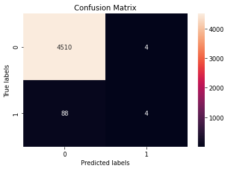

```python
cm = confusion_matrix(y_test, predTest)
ax = plt.subplot()
sns.heatmap(cm, annot=True, fmt='g', ax=ax);  #annot=True to annotate cells, ftm='g' to disable scientific notation

# labels, title and ticks
ax.set_xlabel('Predicted labels');ax.set_ylabel('True labels');
ax.set_title('Confusion Matrix');
```

```python
Recall = sklearn.metrics.recall_score(y_true = y_test, y_pred = predTest)
tn, fp, fn, tp = confusion_matrix(y_true = y_test, y_pred = predTest).ravel()
specificity = tn / (tn+fp)
precision = metrics.precision_score(y_true = y_test, y_pred = predTest)
BalancedAccuracy = metrics.balanced_accuracy_score(y_true = y_test, y_pred = predTest, sample_weight=None, adjusted=False)
F1Score = sklearn.metrics.f1_score(y_true = y_test, y_pred = predTest)
print('Recall: {}, Specificity: {}, Precision: {}, Balanced Accuracy: {}, F1 Score: {}'.format(Recall, specificity, precision, BalancedAccuracy, F1Score))
```

```
Recall: 0.043478260869565216, Specificity: 0.999113867966327, Precision: 0.5, Balanced Accuracy: 0.5212960644179461, F1 Score: 0.08
```

```python
columns = Int_route_combo.columns
feat_import = clf.feature_importances_
res = "\n".join("{} {}".format(x, y) for x, y in zip(columns, feat_import))
print(res)
```

```
OffTeamScoreBefore 0.1
DefTeamScoreBefore 0.02
Quarter 0.04
TimeLeft 0.02
Down 0.04
ToGo 0.08
StartYard 0.04
Hash 0.02
Attempt 0.02
ThrowDepth 0.08
Shotgun 0.0
RPO 0.0
PressureOnPlay 0.02
InterceptionOnPlay 0.0
Angle 0.02
Comeback 0.0
Corner 0.02
Curl 0.02
Dig 0.02
Drag 0.0
Flat 0.08
Go 0.02
No Intended Route 0.02
Other 0.02
Out 0.02
Post 0.02
Screen 0.04
Slant 0.02
Swing 0.02
count_routes 0.04
success 0.04
Yardline 0.04
Success_cat 0.0
SideOfField_Oppo 0.0
SideOfField_Own 0.0
DropType_Basic Screen 0.0
DropType_Other 0.02
DropType_RPO 0.0
DropType_Rollout 0.0
DropType_Spike 0.0
DropType_Stepback 0.0
DropType_Trick 0.0
CoverageScheme_Combination 0.0
CoverageScheme_Cover 0 0.02
CoverageScheme_Cover 1 0.0
CoverageScheme_Cover 2 0.0
CoverageScheme_Cover 3 0.0
CoverageScheme_Cover 4 0.02
CoverageScheme_Cover 6 0.0
CoverageScheme_Man Cover 2 0.0
CoverageScheme_Other 0.0
CoverageScheme_Prevent 0.0
CoverageScheme_Screen 0.0
CoverageScheme_Spike 0.0
```

The same issue was encountered with the adaboost classifier, next oversampling will be implemented to address the class imbalance issue. The SMOTE python package will be used to oversample from the minority class to balance the two classes.

```python
from imblearn.over_sampling import SMOTE
sm = SMOTE(random_state=42)
X_sm, y_sm = sm.fit_resample(X, y)
```

```python
X_train, X_test, y_train, y_test = train_test_split(X_sm, y_sm, test_size=0.25, random_state=42)
```

```python
clf = DecisionTreeClassifier()
clf.fit(X_train, y_train)
predTrain = clf.predict(X_train)
TrainAcc = metrics.accuracy_score(y_true = y_train, y_pred = predTrain)
predTest = clf.predict(X_test)
TestAcc = metrics.accuracy_score(y_true = y_test, y_pred = predTest)
print('The training accuracy is {}, and the testing accuracy is {}'.format(TrainAcc, TestAcc))
```

```
The training accuracy is 1.0, and the testing accuracy is 0.976630856130247
```

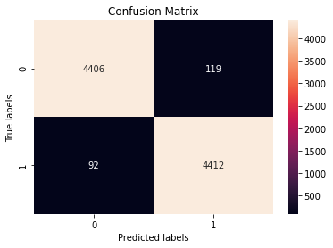

```python
cm = confusion_matrix(y_test, predTest)
ax = plt.subplot()
sns.heatmap(cm, annot=True, fmt='g', ax=ax);  #annot=True to annotate cells, ftm='g' to disable scientific notation

# labels, title and ticks
ax.set_xlabel('Predicted labels');ax.set_ylabel('True labels');
ax.set_title('Confusion Matrix');
```

```python
Recall = sklearn.metrics.recall_score(y_true = y_test, y_pred = predTest)
tn, fp, fn, tp = confusion_matrix(y_true = y_test, y_pred = predTest).ravel()
specificity = tn / (tn+fp)
precision = metrics.precision_score(y_true = y_test, y_pred = predTest)
BalancedAccuracy = metrics.balanced_accuracy_score(y_true = y_test, y_pred = predTest, sample_weight=None, adjusted=False)
F1Score = sklearn.metrics.f1_score(y_true = y_test, y_pred = predTest)
print('Recall: {}, Specificity: {}, Precision: {}, Balanced Accuracy: {}, F1 Score: {}'.format(Recall, specificity, precision, BalancedAccuracy, F1Score))
```

```
Recall: 0.9795737122557726, Specificity: 0.9737016574585635, Precision: 0.9737364820128007, Balanced Accuracy: 0.9766376848571681, F1 Score: 0.9766463752075263
```

```python
columns = Int_route_combo.columns
feat_import = clf.feature_importances_
res = "\n".join("{} {}".format(x, y) for x, y in zip(columns, feat_import))
print(res)
```

```
OffTeamScoreBefore 0.0028191103313675607
DefTeamScoreBefore 0.003131568339897229
Quarter 0.024891347555174102
TimeLeft 0.019020594900168494
Down 0.005384801217543221
ToGo 0.005396725382203112
StartYard 0.009876369113550975
Hash 0.013114557272715403
Attempt 0.001019248274178615
ThrowDepth 0.1928937679481376
Shotgun 0.0047978480706639065
RPO 0.0
PressureOnPlay 0.0617385002419697
InterceptionOnPlay 0.0011765441094520235
Angle 0.001027877214197784
Comeback 0.009407231283450153
Corner 0.002880539986967408
Curl 0.010308071922786611
Dig 0.00594831281410994
Drag 0.004631865240950738
Flat 0.014851408051050787
Go 0.0005452948382905554
No Intended Route 0.00014828507603979282
Other 0.01463819408845873
Out 0.012907310690060724
Post 0.00041732256144551185
Screen 0.0034305128573516044
Slant 0.002864517880271899
Swing 0.008053151259887507
count_routes 0.3221700079732783
success 0.005642916685323824
Yardline 0.055728479969930876
Success_cat 0.000184604135342011
SideOfField_Oppo 0.0006455685266301122
SideOfField_Own 0.0
DropType_Basic Screen 0.0
DropType_Other 0.0
DropType_RPO 0.002631670236830543
DropType_Rollout 0.0
DropType_Spike 0.0001969110776981451
DropType_Stepback 0.0
DropType_Trick 0.002107677202587451
CoverageScheme_Combination 0.010383033607406516
CoverageScheme_Cover 0 0.06731507019236892
CoverageScheme_Cover 1 0.014223976647545988
CoverageScheme_Cover 2 0.02362625883292885
CoverageScheme_Cover 3 0.020957666935361368
CoverageScheme_Cover 4 0.010373879639360319
CoverageScheme_Cover 6 0.014337537999792909
CoverageScheme_Man Cover 2 0.0004428959989639281
CoverageScheme_Other 0.0016867283153265732
CoverageScheme_Prevent 0.005120217171581496
CoverageScheme_Screen 0.0
CoverageScheme_Spike 0.00490402032940027
```

After implementing oversampling to address class imbalance, the decision tree classifier did a much better job at classifying the positive values.  
Next other classifiers will be used to determine the best classifier.

```python
clf = RandomForestClassifier()
clf.fit(X_train, y_train)
predTrain = clf.predict(X_train)
TrainAcc = metrics.accuracy_score(y_true = y_train, y_pred = predTrain)
predTest = clf.predict(X_test)
TestAcc = metrics.accuracy_score(y_true = y_test, y_pred = predTest)
print('The training accuracy is {}, and the testing accuracy is {}'.format(TrainAcc, TestAcc))
```

```
The training accuracy is 1.0, and the testing accuracy is 0.9898106102558423
```

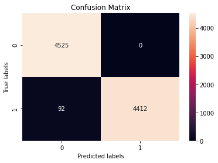

```python
cm = confusion_matrix(y_test, predTest)
ax = plt.subplot()
sns.heatmap(cm, annot=True, fmt='g', ax=ax);  #annot=True to annotate cells, ftm='g' to disable scientific notation

# labels, title and ticks
ax.set_xlabel('Predicted labels');ax.set_ylabel('True labels');
ax.set_title('Confusion Matrix');
```

```python
Recall = sklearn.metrics.recall_score(y_true = y_test, y_pred = predTest)
tn, fp, fn, tp = confusion_matrix(y_true = y_test, y_pred = predTest).ravel()
specificity = tn / (tn+fp)
precision = metrics.precision_score(y_true = y_test, y_pred = predTest)
BalancedAccuracy = metrics.balanced_accuracy_score(y_true = y_test, y_pred = predTest, sample_weight=None, adjusted=False)
F1Score = sklearn.metrics.f1_score(y_true = y_test, y_pred = predTest)
print('Recall: {}, Specificity: {}, Precision: {}, Balanced Accuracy: {}, F1 Score: {}'.format(Recall, specificity, precision, BalancedAccuracy, F1Score))
```

```
Recall: 0.9795737122557726, Specificity: 1.0, Precision: 1.0, Balanced Accuracy: 0.9897868561278863, F1 Score: 0.9896814715118887
```

```python
columns = Int_route_combo.columns
feat_import = clf.feature_importances_
res = "\n".join("{} {}".format(x, y) for x, y in zip(columns, feat_import))
print(res)
```

```
OffTeamScoreBefore 0.012498337458670706
DefTeamScoreBefore 0.011105001617414074
Quarter 0.025567000731109756
TimeLeft 0.018383576449983667
Down 0.0665819132705284
ToGo 0.012418475108874772
StartYard 0.011772921390683106
Hash 0.04330972556104382
Attempt 0.009071265154802395
ThrowDepth 0.10346637737297643
Shotgun 0.018505524681948805
RPO 0.00023538026200627243
PressureOnPlay 0.052386493951721465
InterceptionOnPlay 0.0011014876057103059
Angle 0.003065214145722134
Comeback 0.009035868779532247
Corner 0.021879013200678712
Curl 0.05445086401922595
Dig 0.017304462752286316
Drag 0.03142523080103166
Flat 0.024287993586370002
Go 0.005617370611617461
No Intended Route 0.005162490305679241
Other 0.03372830768975513
Out 0.014757974033034811
Post 0.004859579729416095
Screen 0.007191562468950885
Slant 0.022453625027513722
Swing 0.02744295646801756
count_routes 0.12679039696023686
success 0.012541376078787017
Yardline 0.08130257007912864
Success_cat 0.0035401777997783033
SideOfField_Oppo 0.003646485739042465
SideOfField_Own 0.00040590964783449127
DropType_Basic Screen 6.975845802663797e-06
DropType_Other 0.00048425846425365337
DropType_RPO 0.0019396898333338727
DropType_Rollout 0.0
DropType_Spike 0.013063686988659073
DropType_Stepback 8.986900749335493e-05
DropType_Trick 0.0005944590421093398
CoverageScheme_Combination 0.0021846131235409103
CoverageScheme_Cover 0 0.02925074795241035
CoverageScheme_Cover 1 0.005342519109455173
CoverageScheme_Cover 2 0.02586928805619608
CoverageScheme_Cover 3 0.010682633022680832
CoverageScheme_Cover 4 0.0017113996603121326
CoverageScheme_Cover 6 0.004797316483918296
CoverageScheme_Man Cover 2 1.5201215946217235e-05
CoverageScheme_Other 0.0005801650440573497
CoverageScheme_Prevent 0.004377750008467456
CoverageScheme_Screen 0.0
CoverageScheme_Spike 0.0017165166002495737
```

```python
clf = AdaBoostClassifier()
clf.fit(X_train, y_train)
predTrain = clf.predict(X_train)
TrainAcc = metrics.accuracy_score(y_true = y_train, y_pred = predTrain)
predTest = clf.predict(X_test)
TestAcc = metrics.accuracy_score(y_true = y_test, y_pred = predTest)
print('The training accuracy is {}, and the testing accuracy is {}'.format(TrainAcc, TestAcc))
```

```
The training accuracy is 0.9863393021967879, and the testing accuracy is 0.9859342119836084
```

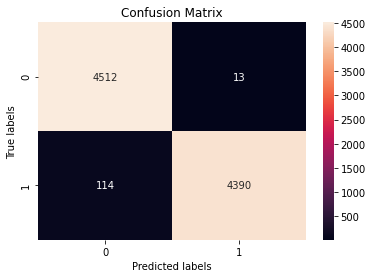

```python
cm = confusion_matrix(y_test, predTest)
ax = plt.subplot()
sns.heatmap(cm, annot=True, fmt='g', ax=ax);  #annot=True to annotate cells, ftm='g' to disable scientific notation

# labels, title and ticks
ax.set_xlabel('Predicted labels');ax.set_ylabel('True labels');
ax.set_title('Confusion Matrix');
```

```python
Recall = sklearn.metrics.recall_score(y_true = y_test, y_pred = predTest)
tn, fp, fn, tp = confusion_matrix(y_true = y_test, y_pred = predTest).ravel()
specificity = tn / (tn+fp)
precision = metrics.precision_score(y_true = y_test, y_pred = predTest)
BalancedAccuracy = metrics.balanced_accuracy_score(y_true = y_test, y_pred = predTest, sample_weight=None, adjusted=False)
F1Score = sklearn.metrics.f1_score(y_true = y_test, y_pred = predTest)
print('Recall: {}, Specificity: {}, Precision: {}, Balanced Accuracy: {}, F1 Score: {}'.format(Recall, specificity, precision, BalancedAccuracy, F1Score))
```

```
Recall: 0.9746891651865008, Specificity: 0.9971270718232044, Precision: 0.997047467635703, Balanced Accuracy: 0.9859081185048526, F1 Score: 0.9857415515886381
```

```python
columns = Int_route_combo.columns
feat_import = clf.feature_importances_
res = "\n".join("{} {}".format(x, y) for x, y in zip(columns, feat_import))
print(res)
```

```
OffTeamScoreBefore 0.0
DefTeamScoreBefore 0.0
Quarter 0.08
TimeLeft 0.0
Down 0.12
ToGo 0.0
StartYard 0.0
Hash 0.08
Attempt 0.0
ThrowDepth 0.04
Shotgun 0.0
RPO 0.0
PressureOnPlay 0.08
InterceptionOnPlay 0.0
Angle 0.0
Comeback 0.0
Corner 0.06
Curl 0.06
Dig 0.06
Drag 0.1
Flat 0.04
Go 0.0
No Intended Route 0.0
Other 0.0
Out 0.08
Post 0.0
Screen 0.0
Slant 0.0
Swing 0.02
count_routes 0.02
success 0.0
Yardline 0.02
Success_cat 0.0
SideOfField_Oppo 0.0
SideOfField_Own 0.0
DropType_Basic Screen 0.0
DropType_Other 0.0
DropType_RPO 0.0
DropType_Rollout 0.0
DropType_Spike 0.0
DropType_Stepback 0.0
DropType_Trick 0.0
CoverageScheme_Combination 0.0
CoverageScheme_Cover 0 0.08
CoverageScheme_Cover 1 0.0
CoverageScheme_Cover 2 0.04
CoverageScheme_Cover 3 0.0
CoverageScheme_Cover 4 0.0
CoverageScheme_Cover 6 0.0
CoverageScheme_Man Cover 2 0.0
CoverageScheme_Other 0.0
CoverageScheme_Prevent 0.02
CoverageScheme_Screen 0.0
CoverageScheme_Spike 0.0
```

#### After running classification with the balanced classes, the random forest model performed the best, now tuning of the models will be performed to see if the performance can be improved.

```python
def print_results(results):
    print('BEST PARAMS: {}\n'.format(results.best_params_))

    means = results.cv_results_['mean_test_score']
    stds = results.cv_results_['std_test_score']
    for mean, std, params in zip(means, stds, results.cv_results_['params']):
        print('{} (+/-{}) for {}'.format(round(mean, 3), round(std * 2, 3), params))
```

```python
clf = DecisionTreeClassifier(ccp_alpha = 0.0, max_depth = None, min_samples_split = 7)
clf.fit(X_train, y_train)
predTrain = clf.predict(X_train)
TrainAcc = metrics.accuracy_score(y_true = y_train, y_pred = predTrain)
predTest = clf.predict(X_test)
TestAcc = metrics.accuracy_score(y_true = y_test, y_pred = predTest)
print('The training accuracy is {}, and the testing accuracy is {}'.format(TrainAcc, TestAcc))
```

```
The training accuracy is 0.9957541074395422, and the testing accuracy is 0.980950271347879
```

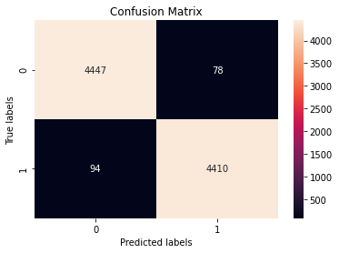

```python
cm = confusion_matrix(y_test, predTest)
ax = plt.subplot()
sns.heatmap(cm, annot=True, fmt='g', ax=ax);  #annot=True to annotate cells, ftm='g' to disable scientific notation

# labels, title and ticks
ax.set_xlabel('Predicted labels');ax.set_ylabel('True labels');
ax.set_title('Confusion Matrix');
```

```python
Recall = sklearn.metrics.recall_score(y_true = y_test, y_pred = predTest)
tn, fp, fn, tp = confusion_matrix(y_true = y_test, y_pred = predTest).ravel()
specificity = tn / (tn+fp)
precision = metrics.precision_score(y_true = y_test, y_pred = predTest)
BalancedAccuracy = metrics.balanced_accuracy_score(y_true = y_test, y_pred = predTest, sample_weight=None, adjusted=False)
F1Score = sklearn.metrics.f1_score(y_true = y_test, y_pred = predTest)
print('Recall: {}, Specificity: {}, Precision: {}, Balanced Accuracy: {}, F1 Score: {}'.format(Recall, specificity, precision, BalancedAccuracy, F1Score))
```

```
Recall: 0.9791296625222025, Specificity: 0.9827624309392266, Precision: 0.982620320855615, Balanced Accuracy: 0.9809460467307145, F1 Score: 0.9808718861209964
```

```python
columns = Int_route_combo.columns
feat_import = clf.feature_importances_
res = "\n".join("{} {}".format(x, y) for x, y in zip(columns, feat_import))
print(res)
```

```
OffTeamScoreBefore 0.002158439126726569
DefTeamScoreBefore 0.0018893663115298002
Quarter 0.024656602766202927
TimeLeft 0.018400074503306253
Down 0.0047296066413114865
ToGo 0.0057442769787310905
StartYard 0.008474207400222585
Hash 0.012523983446604225
Attempt 0.0010307462616650027
ThrowDepth 0.19475119077393144
Shotgun 0.005127115743000041
RPO 0.0
PressureOnPlay 0.06315070955243327
InterceptionOnPlay 0.0011898165277532116
Angle 0.0013543079961529662
Comeback 0.00913707259886646
Corner 0.00211406723430031
Curl 0.009006744262896861
Dig 0.005474030708731387
Drag 0.005751685513881219
Flat 0.013692866727071262
Go 0.00045360718954831137
No Intended Route 0.0001469773339576905
Other 0.014912769763089537
Out 0.012872985784283723
Post 0.00042203031490543766
Screen 0.003543154711714717
Slant 0.0021048127823445058
Swing 0.008094776168268553
count_routes 0.32580435969504246
success 0.004893751394372599
Yardline 0.05636931500661571
Success_cat 0.00025602737418448183
SideOfField_Oppo 0.00040004277216325286
SideOfField_Own 0.0
DropType_Basic Screen 0.0
DropType_Other 0.0
DropType_RPO 0.0022448419833089313
DropType_Rollout 0.0
DropType_Spike 0.0
DropType_Stepback 0.0
DropType_Trick 0.002131453594183723
CoverageScheme_Combination 0.010425932862017418
CoverageScheme_Cover 0 0.06807444144108739
CoverageScheme_Cover 1 0.014309760551976875
CoverageScheme_Cover 2 0.023855001348511755
CoverageScheme_Cover 3 0.021194087244594522
CoverageScheme_Cover 4 0.010490905825521665
CoverageScheme_Cover 6 0.014499277623674124
CoverageScheme_Man Cover 2 0.0004478922425513526
CoverageScheme_Other 0.0015575644903397122
CoverageScheme_Prevent 0.006746145243318524
CoverageScheme_Screen 0.0
CoverageScheme_Spike 0.003391174183104569
```

### Decision Tree Classifier

```python
clf = RandomForestClassifier(ccp_alpha = 0.0, max_depth = 16, min_samples_split = 4)
clf.fit(X_train, y_train)
predTrain = clf.predict(X_train)
TrainAcc = metrics.accuracy_score(y_true = y_train, y_pred = predTrain)
predTest = clf.predict(X_test)
TestAcc = metrics.accuracy_score(y_true = y_test, y_pred = predTest)
print('The training accuracy is {}, and the testing accuracy is {}'.format(TrainAcc, TestAcc))
```

```
The training accuracy is 0.996824810780875, and the testing accuracy is 0.9898106102558423
```

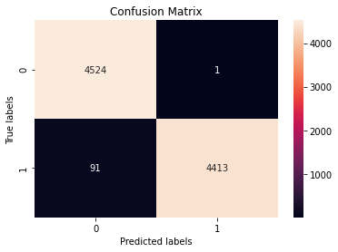

```python
cm = confusion_matrix(y_test, predTest)
ax = plt.subplot()
sns.heatmap(cm, annot=True, fmt='g', ax=ax);  #annot=True to annotate cells, ftm='g' to disable scientific notation

# labels, title and ticks
ax.set_xlabel('Predicted labels');ax.set_ylabel('True labels');
ax.set_title('Confusion Matrix');
```

```python
Recall = sklearn.metrics.recall_score(y_true = y_test, y_pred = predTest)
tn, fp, fn, tp = confusion_matrix(y_true = y_test, y_pred = predTest).ravel()
specificity = tn / (tn+fp)
precision = metrics.precision_score(y_true = y_test, y_pred = predTest)
BalancedAccuracy = metrics.balanced_accuracy_score(y_true = y_test, y_pred = predTest, sample_weight=None, adjusted=False)
F1Score = sklearn.metrics.f1_score(y_true = y_test, y_pred = predTest)
print('Recall: {}, Specificity: {}, Precision: {}, Balanced Accuracy: {}, F1 Score: {}'.format(Recall, specificity, precision, BalancedAccuracy, F1Score))
```

```
Recall: 0.9797957371225577, Specificity: 0.9997790055248619, Precision: 0.9997734481196194, Balanced Accuracy: 0.9897873713237098, F1 Score: 0.989683785602153
```

```python
columns = Int_route_combo.columns
feat_import = clf.feature_importances_
res = "\n".join("{} {}".format(x, y) for x, y in zip(columns, feat_import))
print(res)
```

```
OffTeamScoreBefore 0.011265759231853736
DefTeamScoreBefore 0.008943327578490295
Quarter 0.02440926662864519
TimeLeft 0.015647050375044363
Down 0.0595366895978339
ToGo 0.012748171658405177
StartYard 0.009758355461257197
Hash 0.03919080640722251
Attempt 0.010088396946797348
ThrowDepth 0.10045401595000002
Shotgun 0.0165662112834593
RPO 0.00035140060397543
PressureOnPlay 0.056493458124861985
InterceptionOnPlay 0.0011050109989261126
Angle 0.003098900769761302
Comeback 0.007016964603810495
Corner 0.028525863905974256
Curl 0.06095748386590319
Dig 0.01572626238165765
Drag 0.04120007797820426
Flat 0.028437838577479998
Go 0.006282964701549258
No Intended Route 0.00449512776791968
Other 0.02942493910309292
Out 0.015387263394511455
Post 0.0032528886540755465
Screen 0.005831429967364215
Slant 0.02307029612565479
Swing 0.028398283805328953
count_routes 0.14176123358867948
success 0.010269679104628771
Yardline 0.07218899028805309
Success_cat 0.0033698006689757533
SideOfField_Oppo 0.003234652705278054
SideOfField_Own 0.000533051306977161
DropType_Basic Screen 2.7350624828111064e-06
DropType_Other 0.0002823118189179102
DropType_RPO 0.0019018017831955972
DropType_Rollout 0.0
DropType_Spike 0.015263888409569786
DropType_Stepback 0.00010746558376147812
DropType_Trick 0.00048708554460989413
CoverageScheme_Combination 0.002063892512226972
CoverageScheme_Cover 0 0.031234412437826112
CoverageScheme_Cover 1 0.0046914524229923925
CoverageScheme_Cover 2 0.017639851511068526
CoverageScheme_Cover 3 0.01291933055747765
CoverageScheme_Cover 4 0.0013000326799310516
CoverageScheme_Cover 6 0.004625301139849926
CoverageScheme_Man Cover 2 1.4671720897271993e-05
CoverageScheme_Other 0.000913337262138153
CoverageScheme_Prevent 0.006001339238661669
CoverageScheme_Screen 0.0
CoverageScheme_Spike 0.0015291762027399487
```

### Random Forest Classifier

```python
clf = AdaBoostClassifier(learning_rate = 1, n_estimators = 100)
clf.fit(X_train, y_train)
predTrain = clf.predict(X_train)
TrainAcc = metrics.accuracy_score(y_true = y_train, y_pred = predTrain)
predTest = clf.predict(X_test)
TestAcc = metrics.accuracy_score(y_true = y_test, y_pred = predTest)
print('The training accuracy is {}, and the testing accuracy is {}'.format(TrainAcc, TestAcc))
```

```
The training accuracy is 0.9895144914159129, and the testing accuracy is 0.9892568390740946
```

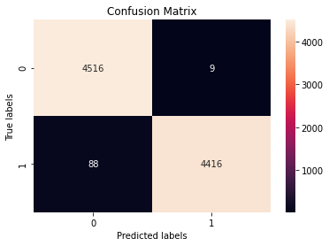

```python
cm = confusion_matrix(y_test, predTest)
ax = plt.subplot()
sns.heatmap(cm, annot=True, fmt='g', ax=ax);  #annot=True to annotate cells, ftm='g' to disable scientific notation

# labels, title and ticks
ax.set_xlabel('Predicted labels');ax.set_ylabel('True labels');
ax.set_title('Confusion Matrix');
```

```python
Recall = sklearn.metrics.recall_score(y_true = y_test, y_pred = predTest)
tn, fp, fn, tp = confusion_matrix(y_true = y_test, y_pred = predTest).ravel()
specificity = tn / (tn+fp)
precision = metrics.precision_score(y_true = y_test, y_pred = predTest)
BalancedAccuracy = metrics.balanced_accuracy_score(y_true = y_test, y_pred = predTest, sample_weight=None, adjusted=False)
F1Score = sklearn.metrics.f1_score(y_true = y_test, y_pred = predTest)
print('Recall: {}, Specificity: {}, Precision: {}, Balanced Accuracy: {}, F1 Score: {}'.format(Recall, specificity, precision, BalancedAccuracy, F1Score))
```

```
Recall: 0.9804618117229129, Specificity: 0.9980110497237569, Precision: 0.9979661016949153, Balanced Accuracy: 0.9892364307233349, F1 Score: 0.9891365214469705
```

### Adaboost Classifier

#### Both training and testing accuracy increased slightly. Recall, specificity, Precision, Balanced Accuracy and F1 all increased slightly as well.

```python
columns = Int_route_combo.columns
feat_import = clf.feature_importances_
res = "\n".join("{} {}".format(x, y) for x, y in zip(columns, feat_import))
print(res)
```

```
OffTeamScoreBefore 0.03
DefTeamScoreBefore 0.02
Quarter 0.06
TimeLeft 0.0
Down 0.08
ToGo 0.01
StartYard 0.01
Hash 0.05
Attempt 0.01
ThrowDepth 0.06
Shotgun 0.0
RPO 0.01
PressureOnPlay 0.05
InterceptionOnPlay 0.01
Angle 0.0
Comeback 0.04
Corner 0.04
Curl 0.04
Dig 0.03
Drag 0.05
Flat 0.05
Go 0.0
No Intended Route 0.0
Other 0.03
Out 0.04
Post 0.01
Screen 0.01
Slant 0.05
Swing 0.03
count_routes 0.01
success 0.01
Yardline 0.01
Success_cat 0.0
SideOfField_Oppo 0.0
SideOfField_Own 0.0
DropType_Basic Screen 0.0
DropType_Other 0.0
DropType_RPO 0.0
DropType_Rollout 0.0
DropType_Spike 0.0
DropType_Stepback 0.0
DropType_Trick 0.0
CoverageScheme_Combination 0.0
CoverageScheme_Cover 0 0.04
CoverageScheme_Cover 1 0.0
CoverageScheme_Cover 2 0.03
CoverageScheme_Cover 3 0.05
CoverageScheme_Cover 4 0.0
CoverageScheme_Cover 6 0.0
CoverageScheme_Man Cover 2 0.0
CoverageScheme_Other 0.01
CoverageScheme_Prevent 0.01
CoverageScheme_Screen 0.0
CoverageScheme_Spike 0.01
```

### Classifier Results

#### Next, we will remove variables other than those that correlate with route combinations and coverages ans rerun the classifiers to determine the best fit, and most influential route combinations and coverage schemes.

```python
Int_route_combo = Int_route_combo.drop(['OffTeamScoreBefore', 'DefTeamScoreBefore', 'Quarter', 'TimeLeft', 'Down', 'ToGo', 'StartYard', 'Hash', 'Attempt', 'ThrowDepth', 'RPO', 'PressureOnPlay', 'success', 'Success_cat', 'SideOfField_Oppo', 'SideOfField_Own'], axis = 1)
```

```python
X = Int_route_combo.drop('InterceptionOnPlay',axis=1)
y = Int_route_combo['InterceptionOnPlay']
```

```python
from imblearn.over_sampling import SMOTE
sm = SMOTE(random_state=42)
X_sm, y_sm = sm.fit_resample(X, y)
```

```python
X_train, X_test, y_train, y_test = train_test_split(X_sm, y_sm, test_size=0.25, random_state=42)
```

```python
clf = DecisionTreeClassifier(class_weight = 'balanced')
clf.fit(X_train, y_train)
predTrain = clf.predict(X_train)
accuracyTrain = metrics.accuracy_score(y_true = y_train, y_pred = predTrain)
predTest = clf.predict(X_test)
accuracyTest = metrics.accuracy_score (y_true = y_test, y_pred = predTest)
print('The training accuracy is {}, and the testing accuracy is {}'.format(accuracyTrain, accuracyTest))
```

```
The training accuracy is 0.9996307919512646, and the testing accuracy is 0.9744157714032562
```

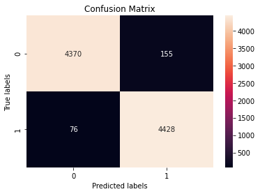

```python
cm = confusion_matrix(y_test, predTest)
ax = plt.subplot()
sns.heatmap(cm, annot=True, fmt='g', ax=ax);  #annot=True to annotate cells, ftm='g' to disable scientific notation

# labels, title and ticks
ax.set_xlabel('Predicted labels');ax.set_ylabel('True labels');
ax.set_title('Confusion Matrix');
```

```python
Recall = sklearn.metrics.recall_score(y_true = y_test, y_pred = predTest)
tn, fp, fn, tp = confusion_matrix(y_true = y_test, y_pred = predTest).ravel()
specificity = tn / (tn+fp)
precision = metrics.precision_score(y_true = y_test, y_pred = predTest)
BalancedAccuracy = metrics.balanced_accuracy_score(y_true = y_test, y_pred = predTest, sample_weight=None, adjusted=False)
F1Score = sklearn.metrics.f1_score(y_true = y_test, y_pred = predTest)
print('Recall: {}, Specificity: {}, Precision: {}, Balanced Accuracy: {}, F1 Score: {}'.format(Recall, specificity, precision, BalancedAccuracy, F1Score))
```

```
Recall: 0.9831261101243339, Specificity: 0.9657458563535911, Precision: 0.9661793584987999, Balanced Accuracy: 0.9744359832389625, F1 Score: 0.9745790689996698
```

```python
columns = X.columns
feat_import = clf.feature_importances_
res = "\n".join("{} {}".format(x, y) for x, y in zip(columns, feat_import))
print(res)
```

```
Shotgun 0.012612680035490096
Angle 0.002722228160596157
Comeback 0.0131649989171816
Corner 0.020783394913696983
Curl 0.03701197334088828
Dig 0.031367781698834266
Drag 0.02548124300035063
Flat 0.0322196064170121
Go 0.05193550936158054
No Intended Route 0.07842180154057993
Other 0.012351579638034854
Out 0.032647827555200896
Post 0.03841164032711454
Screen 0.004520040064093078
Slant 0.017609805057436284
Swing 0.05300821939911888
count_routes 0.030833121072746772
Yardline 0.11497459613504946
DropType_Basic Screen 0.0007748104522233726
DropType_Other 0.0006921189146831166
DropType_RPO 0.003489366775174693
DropType_Rollout 0.004871966374306924
DropType_Spike 0.0
DropType_Stepback 0.015434211307753118
DropType_Trick 0.0018645842746596475
CoverageScheme_Combination 0.0037695484872695166
CoverageScheme_Cover 0 0.02592863213553294
CoverageScheme_Cover 1 0.04421224840281434
CoverageScheme_Cover 2 0.0426868018919173
CoverageScheme_Cover 3 0.051073512399856934
CoverageScheme_Cover 4 0.07184407645956016
CoverageScheme_Cover 6 0.028616412167213688
CoverageScheme_Man Cover 2 0.04150002786085014
CoverageScheme_Other 0.001771399739200576
CoverageScheme_Prevent 0.007232969081427286
CoverageScheme_Screen 0.022458973868178776
CoverageScheme_Spike 0.0002957557129332363
CoverageScheme_Tampa 2 0.02140453705943878
```

```python
clf = RandomForestClassifier()
clf.fit(X_train, y_train)
predTrain = clf.predict(X_train)
TrainAcc = metrics.accuracy_score(y_true = y_train, y_pred = predTrain)
predTest = clf.predict(X_test)
TestAcc = metrics.accuracy_score(y_true = y_test, y_pred = predTest)
print('The training accuracy is {}, and the testing accuracy is {}'.format(TrainAcc, TestAcc))
```

```
The training accuracy is 0.9996307919512646, and the testing accuracy is 0.989146084837745
```

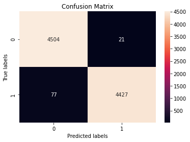

```python
cm = confusion_matrix(y_test, predTest)
ax = plt.subplot()
sns.heatmap(cm, annot=True, fmt='g', ax=ax);  #annot=True to annotate cells, ftm='g' to disable scientific notation

# labels, title and ticks
ax.set_xlabel('Predicted labels');ax.set_ylabel('True labels');
ax.set_title('Confusion Matrix');
```

```python
Recall = sklearn.metrics.recall_score(y_true = y_test, y_pred = predTest)
tn, fp, fn, tp = confusion_matrix(y_true = y_test, y_pred = predTest).ravel()
specificity = tn / (tn+fp)
precision = metrics.precision_score(y_true = y_test, y_pred = predTest)
BalancedAccuracy = metrics.balanced_accuracy_score(y_true = y_test, y_pred = predTest, sample_weight=None, adjusted=False)
F1Score = sklearn.metrics.f1_score(y_true = y_test, y_pred = predTest)
print('Recall: {}, Specificity: {}, Precision: {}, Balanced Accuracy: {}, F1 Score: {}'.format(Recall, specificity, precision, BalancedAccuracy, F1Score))
```

```
Recall: 0.9829040852575488, Specificity: 0.9953591160220995, Precision: 0.9952787769784173, Balanced Accuracy: 0.9891316006398241, F1 Score: 0.9890527256478999
```

```python
columns = X.columns
feat_import = clf.feature_importances_
res = "\n".join("{} {}".format(x, y) for x, y in zip(columns, feat_import))
print(res)
```

```
Shotgun 0.013714440743720722
Angle 0.003399066062292705
Comeback 0.014112560368134077
Corner 0.024581690975043716
Curl 0.05092431312970755
Dig 0.03956435816676663
Drag 0.028766042423149486
Flat 0.034913203187941576
Go 0.051703165337987675
No Intended Route 0.04304628746345096
Other 0.023695331221453033
Out 0.03976418832517245
Post 0.0426637815044453
Screen 0.02457266417173792
Slant 0.024078421255518193
Swing 0.03722615112625975
count_routes 0.03770150071267106
Yardline 0.12280766239888422
DropType_Basic Screen 0.0038571267826113414
DropType_Other 0.00012092318841602835
DropType_RPO 0.006215058275613553
DropType_Rollout 0.017727894298299237
DropType_Spike 9.104030252631923e-05
DropType_Stepback 0.008793467147031171
DropType_Trick 0.0004846939201582907
CoverageScheme_Combination 0.0027238133710609687
CoverageScheme_Cover 0 0.017594663337380172
CoverageScheme_Cover 1 0.057528489987545645
CoverageScheme_Cover 2 0.04439432116571062
CoverageScheme_Cover 3 0.05427554482829942
CoverageScheme_Cover 4 0.04624657738089888
CoverageScheme_Cover 6 0.018646875470994938
CoverageScheme_Man Cover 2 0.02827302055453473
CoverageScheme_Other 0.000953662261713015
CoverageScheme_Prevent 0.003975578328702473
CoverageScheme_Screen 0.018734591948058026
CoverageScheme_Spike 7.610267577955964e-05
CoverageScheme_Tampa 2 0.012051726200328673
```

```python
clf = AdaBoostClassifier()
clf.fit(X_train, y_train)
predTrain = clf.predict(X_train)
TrainAcc = metrics.accuracy_score(y_true = y_train, y_pred = predTrain)
predTest = clf.predict(X_test)
TestAcc = metrics.accuracy_score(y_true = y_test, y_pred = predTest)
print('The training accuracy is {}, and the testing accuracy is {}'.format(TrainAcc, TestAcc))
```

```
The training accuracy is 0.945246446372531, and the testing accuracy is 0.938088381880607
```

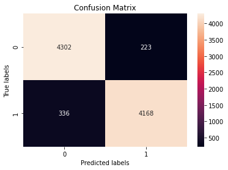

```python
cm = confusion_matrix(y_test, predTest)
ax = plt.subplot()
sns.heatmap(cm, annot=True, fmt='g', ax=ax);  #annot=True to annotate cells, ftm='g' to disable scientific notation

# labels, title and ticks
ax.set_xlabel('Predicted labels');ax.set_ylabel('True labels');
ax.set_title('Confusion Matrix');
```

```python
Recall = sklearn.metrics.recall_score(y_true = y_test, y_pred = predTest)
tn, fp, fn, tp = confusion_matrix(y_true = y_test, y_pred = predTest).ravel()
specificity = tn / (tn+fp)
precision = metrics.precision_score(y_true = y_test, y_pred = predTest)
BalancedAccuracy = metrics.balanced_accuracy_score(y_true = y_test, y_pred = predTest, sample_weight=None, adjusted=False)
F1Score = sklearn.metrics.f1_score(y_true = y_test, y_pred = predTest)
print('Recall: {}, Specificity: {}, Precision: {}, Balanced Accuracy: {}, F1 Score: {}'.format(Recall, specificity, precision, BalancedAccuracy, F1Score))
```

```
Recall: 0.9253996447602132, Specificity: 0.9507182320441989, Precision: 0.9492143019813254, Balanced Accuracy: 0.938058938402206, F1 Score: 0.9371557054525014
```

```python
columns = X.columns
feat_import = clf.feature_importances_
res = "\n".join("{} {}".format(x, y) for x, y in zip(columns, feat_import))
print(res)
```

```
Shotgun 0.0
Angle 0.0
Comeback 0.02
Corner 0.04
Curl 0.08
Dig 0.06
Drag 0.04
Flat 0.04
Go 0.08
No Intended Route 0.04
Other 0.02
Out 0.06
Post 0.06
Screen 0.02
Slant 0.04
Swing 0.04
count_routes 0.04
Yardline 0.0
DropType_Basic Screen 0.0
DropType_Other 0.0
DropType_RPO 0.0
DropType_Rollout 0.0
DropType_Spike 0.0
DropType_Stepback 0.0
DropType_Trick 0.0
CoverageScheme_Combination 0.0
CoverageScheme_Cover 0 0.02
CoverageScheme_Cover 1 0.06
CoverageScheme_Cover 2 0.04
CoverageScheme_Cover 3 0.06
CoverageScheme_Cover 4 0.04
CoverageScheme_Cover 6 0.02
CoverageScheme_Man Cover 2 0.02
CoverageScheme_Other 0.0
CoverageScheme_Prevent 0.0
CoverageScheme_Screen 0.04
CoverageScheme_Spike 0.0
CoverageScheme_Tampa 2 0.02
```

```python
clf = DecisionTreeClassifier()
parameters = {
    'min_samples_split': [2, 3, 4, 5, 6, 7],
    'max_depth': [1, 2, 4, 8, 16, None],
    'ccp_alpha': [0.0, 0.001, 0.005, 0.01, 0.05, 0.1, 0.5, 1]
}
cv = GridSearchCV(clf, parameters, cv=5)
cv.fit(X_train, y_train)

print_results(cv)
```

```
BEST PARAMS: {'ccp_alpha': 0.0, 'max_depth': None, 'min_samples_split': 6}

0.584 (+/-0.004) for {'ccp_alpha': 0.0, 'max_depth': 1, 'min_samples_split': 2}
0.584 (+/-0.004) for {'ccp_alpha': 0.0, 'max_depth': 1, 'min_samples_split': 3}
0.584 (+/-0.004) for {'ccp_alpha': 0.0, 'max_depth': 1, 'min_samples_split': 4}
0.584 (+/-0.004) for {'ccp_alpha': 0.0, 'max_depth': 1, 'min_samples_split': 5}
0.584 (+/-0.004) for {'ccp_alpha': 0.0, 'max_depth': 1, 'min_samples_split': 6}
0.584 (+/-0.004) for {'ccp_alpha': 0.0, 'max_depth': 1, 'min_samples_split': 7}
0.644 (+/-0.016) for {'ccp_alpha': 0.0, 'max_depth': 2, 'min_samples_split': 2}
0.644 (+/-0.016) for {'ccp_alpha': 0.0, 'max_depth': 2, 'min_samples_split': 3}
0.644 (+/-0.016) for {'ccp_alpha': 0.0, 'max_depth': 2, 'min_samples_split': 4}
0.644 (+/-0.016) for {'ccp_alpha': 0.0, 'max_depth': 2, 'min_samples_split': 5}
0.644 (+/-0.016) for {'ccp_alpha': 0.0, 'max_depth': 2, 'min_samples_split': 6}
0.644 (+/-0.016) for {'ccp_alpha': 0.0, 'max_depth': 2, 'min_samples_split': 7}
0.713 (+/-0.011) for {'ccp_alpha': 0.0, 'max_depth': 4, 'min_samples_split': 2}
0.713 (+/-0.011) for {'ccp_alpha': 0.0, 'max_depth': 4, 'min_samples_split': 3}
0.713 (+/-0.011) for {'ccp_alpha': 0.0, 'max_depth': 4, 'min_samples_split': 4}
0.713 (+/-0.011) for {'ccp_alpha': 0.0, 'max_depth': 4, 'min_samples_split': 5}
0.713 (+/-0.011) for {'ccp_alpha': 0.0, 'max_depth': 4, 'min_samples_split': 6}
0.713 (+/-0.011) for {'ccp_alpha': 0.0, 'max_depth': 4, 'min_samples_split': 7}
0.833 (+/-0.026) for {'ccp_alpha': 0.0, 'max_depth': 8, 'min_samples_split': 2}
0.834 (+/-0.026) for {'ccp_alpha': 0.0, 'max_depth': 8, 'min_samples_split': 3}
0.834 (+/-0.026) for {'ccp_alpha': 0.0, 'max_depth': 8, 'min_samples_split': 4}
0.834 (+/-0.026) for {'ccp_alpha': 0.0, 'max_depth': 8, 'min_samples_split': 5}
0.834 (+/-0.026) for {'ccp_alpha': 0.0, 'max_depth': 8, 'min_samples_split': 6}
0.834 (+/-0.025) for {'ccp_alpha': 0.0, 'max_depth': 8, 'min_samples_split': 7}
0.955 (+/-0.01) for {'ccp_alpha': 0.0, 'max_depth': 16, 'min_samples_split': 2}
0.956 (+/-0.011) for {'ccp_alpha': 0.0, 'max_depth': 16, 'min_samples_split': 3}
0.956 (+/-0.01) for {'ccp_alpha': 0.0, 'max_depth': 16, 'min_samples_split': 4}
0.957 (+/-0.01) for {'ccp_alpha': 0.0, 'max_depth': 16, 'min_samples_split': 5}
0.957 (+/-0.01) for {'ccp_alpha': 0.0, 'max_depth': 16, 'min_samples_split': 6}
0.957 (+/-0.01) for {'ccp_alpha': 0.0, 'max_depth': 16, 'min_samples_split': 7}
0.971 (+/-0.002) for {'ccp_alpha': 0.0, 'max_depth': None, 'min_samples_split': 2}
0.972 (+/-0.003) for {'ccp_alpha': 0.0, 'max_depth': None, 'min_samples_split': 3}
0.972 (+/-0.003) for {'ccp_alpha': 0.0, 'max_depth': None, 'min_samples_split': 4}
0.973 (+/-0.002) for {'ccp_alpha': 0.0, 'max_depth': None, 'min_samples_split': 5}
0.973 (+/-0.004) for {'ccp_alpha': 0.0, 'max_depth': None, 'min_samples_split': 6}
0.973 (+/-0.004) for {'ccp_alpha': 0.0, 'max_depth': None, 'min_samples_split': 7}
0.584 (+/-0.004) for {'ccp_alpha': 0.001, 'max_depth': 1, 'min_samples_split': 2}
0.584 (+/-0.004) for {'ccp_alpha': 0.001, 'max_depth': 1, 'min_samples_split': 3}
```

[output cut: 235 more lines]

```
0.5 (+/-0.0) for {'ccp_alpha': 1, 'max_depth': 8, 'min_samples_split': 5}
0.5 (+/-0.0) for {'ccp_alpha': 1, 'max_depth': 8, 'min_samples_split': 6}
0.5 (+/-0.0) for {'ccp_alpha': 1, 'max_depth': 8, 'min_samples_split': 7}
0.5 (+/-0.0) for {'ccp_alpha': 1, 'max_depth': 16, 'min_samples_split': 2}
0.5 (+/-0.0) for {'ccp_alpha': 1, 'max_depth': 16, 'min_samples_split': 3}
0.5 (+/-0.0) for {'ccp_alpha': 1, 'max_depth': 16, 'min_samples_split': 4}
0.5 (+/-0.0) for {'ccp_alpha': 1, 'max_depth': 16, 'min_samples_split': 5}
0.5 (+/-0.0) for {'ccp_alpha': 1, 'max_depth': 16, 'min_samples_split': 6}
0.5 (+/-0.0) for {'ccp_alpha': 1, 'max_depth': 16, 'min_samples_split': 7}
0.5 (+/-0.0) for {'ccp_alpha': 1, 'max_depth': None, 'min_samples_split': 2}
0.5 (+/-0.0) for {'ccp_alpha': 1, 'max_depth': None, 'min_samples_split': 3}
0.5 (+/-0.0) for {'ccp_alpha': 1, 'max_depth': None, 'min_samples_split': 4}
0.5 (+/-0.0) for {'ccp_alpha': 1, 'max_depth': None, 'min_samples_split': 5}
0.5 (+/-0.0) for {'ccp_alpha': 1, 'max_depth': None, 'min_samples_split': 6}
0.5 (+/-0.0) for {'ccp_alpha': 1, 'max_depth': None, 'min_samples_split': 7}
```

```python
clf = DecisionTreeClassifier(ccp_alpha = 0.0, max_depth = None, min_samples_split = 6)
clf.fit(X_train, y_train)
predTrain = clf.predict(X_train)
accuracyTrain = metrics.accuracy_score(y_true = y_train, y_pred = predTrain)
predTest = clf.predict(X_test)
accuracyTest = metrics.accuracy_score (y_true = y_test, y_pred = predTest)
print('The training accuracy is {}, and the testing accuracy is {}'.format(accuracyTrain, accuracyTest))
```

```
The training accuracy is 0.9937234631714972, and the testing accuracy is 0.9781814154391405
```

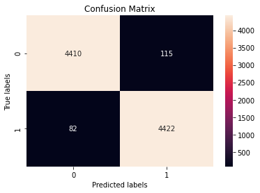

```python
cm = confusion_matrix(y_test, predTest)
ax = plt.subplot()
sns.heatmap(cm, annot=True, fmt='g', ax=ax);
# labels, title and ticks
ax.set_xlabel('Predicted labels');ax.set_ylabel('True labels');
ax.set_title('Confusion Matrix');
```

```python
Recall = sklearn.metrics.recall_score(y_true = y_test, y_pred = predTest)
tn, fp, fn, tp = confusion_matrix(y_true = y_test, y_pred = predTest).ravel()
specificity = tn / (tn+fp)
precision = metrics.precision_score(y_true = y_test, y_pred = predTest)
BalancedAccuracy = metrics.balanced_accuracy_score(y_true = y_test, y_pred = predTest, sample_weight=None, adjusted=False)
F1Score = sklearn.metrics.f1_score(y_true = y_test, y_pred = predTest)
print('Recall: {}, Specificity: {}, Precision: {}, Balanced Accuracy: {}, F1 Score: {}'.format(Recall, specificity, precision, BalancedAccuracy, F1Score))
```

```
Recall: 0.9817939609236235, Specificity: 0.974585635359116, Precision: 0.9746528543090147, Balanced Accuracy: 0.9781897981413697, F1 Score: 0.9782103749585223
```

```python
columns = X.columns
feat_import = clf.feature_importances_
res = "\n".join("{} {}".format(x, y) for x, y in zip(columns, feat_import))
print(res)
```

```
Shotgun 0.012255859222618883
Angle 0.00303436020927889
Comeback 0.013548370749569801
Corner 0.0208252855301092
Curl 0.03722563837045063
Dig 0.030925258121922674
Drag 0.025556862196165448
Flat 0.0316832576527833
Go 0.0512058129971069
No Intended Route 0.07956333552950529
Other 0.01269463039147397
Out 0.032850145957722746
Post 0.038636845562956844
Screen 0.004452277108265377
Slant 0.01822242979123346
Swing 0.05383358955851208
count_routes 0.030462908920933077
Yardline 0.10881645523186131
DropType_Basic Screen 0.000674699890634427
DropType_Other 0.0007023214931670747
DropType_RPO 0.0035485400697376607
DropType_Rollout 0.004723939820830325
DropType_Spike 0.00030008540379620113
DropType_Stepback 0.015972275699367537
DropType_Trick 0.001755035346545127
CoverageScheme_Combination 0.0038228751439793973
CoverageScheme_Cover 0 0.02601245673483097
CoverageScheme_Cover 1 0.044783941666812974
CoverageScheme_Cover 2 0.04330413830173307
CoverageScheme_Cover 3 0.05126489179832116
CoverageScheme_Cover 4 0.07282817329536705
CoverageScheme_Cover 6 0.029096071504463014
CoverageScheme_Man Cover 2 0.04204205241400907
CoverageScheme_Other 0.0017973369158585234
CoverageScheme_Prevent 0.007335802005071942
CoverageScheme_Screen 0.022795295069629587
CoverageScheme_Spike 0.0
CoverageScheme_Tampa 2 0.021446744323375146
```

```python
clf = RandomForestClassifier()
parameters = {
    'max_depth': [1, 2, 4, 8, 16, None],
    'ccp_alpha': [0.0, 0.001, 0.01, 0.1, 0.5, 1],
    'min_samples_split': [2, 4, 6, 8]
}
cv = GridSearchCV(clf, parameters, cv=3)
cv.fit(X_train, y_train)

print_results(cv)
```

```
BEST PARAMS: {'ccp_alpha': 0.0, 'max_depth': None, 'min_samples_split': 2}

0.705 (+/-0.023) for {'ccp_alpha': 0.0, 'max_depth': 1, 'min_samples_split': 2}
0.713 (+/-0.036) for {'ccp_alpha': 0.0, 'max_depth': 1, 'min_samples_split': 4}
0.723 (+/-0.018) for {'ccp_alpha': 0.0, 'max_depth': 1, 'min_samples_split': 6}
0.723 (+/-0.024) for {'ccp_alpha': 0.0, 'max_depth': 1, 'min_samples_split': 8}
0.745 (+/-0.007) for {'ccp_alpha': 0.0, 'max_depth': 2, 'min_samples_split': 2}
0.741 (+/-0.011) for {'ccp_alpha': 0.0, 'max_depth': 2, 'min_samples_split': 4}
0.742 (+/-0.009) for {'ccp_alpha': 0.0, 'max_depth': 2, 'min_samples_split': 6}
0.739 (+/-0.014) for {'ccp_alpha': 0.0, 'max_depth': 2, 'min_samples_split': 8}
0.787 (+/-0.032) for {'ccp_alpha': 0.0, 'max_depth': 4, 'min_samples_split': 2}
0.785 (+/-0.006) for {'ccp_alpha': 0.0, 'max_depth': 4, 'min_samples_split': 4}
0.785 (+/-0.022) for {'ccp_alpha': 0.0, 'max_depth': 4, 'min_samples_split': 6}
0.789 (+/-0.009) for {'ccp_alpha': 0.0, 'max_depth': 4, 'min_samples_split': 8}
0.886 (+/-0.005) for {'ccp_alpha': 0.0, 'max_depth': 8, 'min_samples_split': 2}
0.886 (+/-0.005) for {'ccp_alpha': 0.0, 'max_depth': 8, 'min_samples_split': 4}
0.886 (+/-0.008) for {'ccp_alpha': 0.0, 'max_depth': 8, 'min_samples_split': 6}
0.886 (+/-0.01) for {'ccp_alpha': 0.0, 'max_depth': 8, 'min_samples_split': 8}
0.975 (+/-0.006) for {'ccp_alpha': 0.0, 'max_depth': 16, 'min_samples_split': 2}
0.975 (+/-0.007) for {'ccp_alpha': 0.0, 'max_depth': 16, 'min_samples_split': 4}
0.975 (+/-0.009) for {'ccp_alpha': 0.0, 'max_depth': 16, 'min_samples_split': 6}
0.974 (+/-0.006) for {'ccp_alpha': 0.0, 'max_depth': 16, 'min_samples_split': 8}
0.987 (+/-0.001) for {'ccp_alpha': 0.0, 'max_depth': None, 'min_samples_split': 2}
0.987 (+/-0.0) for {'ccp_alpha': 0.0, 'max_depth': None, 'min_samples_split': 4}
0.987 (+/-0.001) for {'ccp_alpha': 0.0, 'max_depth': None, 'min_samples_split': 6}
0.986 (+/-0.0) for {'ccp_alpha': 0.0, 'max_depth': None, 'min_samples_split': 8}
0.712 (+/-0.027) for {'ccp_alpha': 0.001, 'max_depth': 1, 'min_samples_split': 2}
0.699 (+/-0.011) for {'ccp_alpha': 0.001, 'max_depth': 1, 'min_samples_split': 4}
0.72 (+/-0.013) for {'ccp_alpha': 0.001, 'max_depth': 1, 'min_samples_split': 6}
0.716 (+/-0.013) for {'ccp_alpha': 0.001, 'max_depth': 1, 'min_samples_split': 8}
0.749 (+/-0.009) for {'ccp_alpha': 0.001, 'max_depth': 2, 'min_samples_split': 2}
0.736 (+/-0.031) for {'ccp_alpha': 0.001, 'max_depth': 2, 'min_samples_split': 4}
0.733 (+/-0.024) for {'ccp_alpha': 0.001, 'max_depth': 2, 'min_samples_split': 6}
0.749 (+/-0.007) for {'ccp_alpha': 0.001, 'max_depth': 2, 'min_samples_split': 8}
0.792 (+/-0.014) for {'ccp_alpha': 0.001, 'max_depth': 4, 'min_samples_split': 2}
0.784 (+/-0.009) for {'ccp_alpha': 0.001, 'max_depth': 4, 'min_samples_split': 4}
0.787 (+/-0.023) for {'ccp_alpha': 0.001, 'max_depth': 4, 'min_samples_split': 6}
0.782 (+/-0.003) for {'ccp_alpha': 0.001, 'max_depth': 4, 'min_samples_split': 8}
0.861 (+/-0.009) for {'ccp_alpha': 0.001, 'max_depth': 8, 'min_samples_split': 2}
0.864 (+/-0.003) for {'ccp_alpha': 0.001, 'max_depth': 8, 'min_samples_split': 4}
```

[output cut: 91 more lines]

```
0.5 (+/-0.001) for {'ccp_alpha': 1, 'max_depth': 4, 'min_samples_split': 4}
0.5 (+/-0.001) for {'ccp_alpha': 1, 'max_depth': 4, 'min_samples_split': 6}
0.5 (+/-0.0) for {'ccp_alpha': 1, 'max_depth': 4, 'min_samples_split': 8}
0.5 (+/-0.0) for {'ccp_alpha': 1, 'max_depth': 8, 'min_samples_split': 2}
0.5 (+/-0.001) for {'ccp_alpha': 1, 'max_depth': 8, 'min_samples_split': 4}
0.5 (+/-0.0) for {'ccp_alpha': 1, 'max_depth': 8, 'min_samples_split': 6}
0.5 (+/-0.0) for {'ccp_alpha': 1, 'max_depth': 8, 'min_samples_split': 8}
0.5 (+/-0.001) for {'ccp_alpha': 1, 'max_depth': 16, 'min_samples_split': 2}
0.5 (+/-0.001) for {'ccp_alpha': 1, 'max_depth': 16, 'min_samples_split': 4}
0.5 (+/-0.001) for {'ccp_alpha': 1, 'max_depth': 16, 'min_samples_split': 6}
0.5 (+/-0.0) for {'ccp_alpha': 1, 'max_depth': 16, 'min_samples_split': 8}
0.5 (+/-0.001) for {'ccp_alpha': 1, 'max_depth': None, 'min_samples_split': 2}
0.5 (+/-0.0) for {'ccp_alpha': 1, 'max_depth': None, 'min_samples_split': 4}
0.5 (+/-0.0) for {'ccp_alpha': 1, 'max_depth': None, 'min_samples_split': 6}
0.5 (+/-0.0) for {'ccp_alpha': 1, 'max_depth': None, 'min_samples_split': 8}
```

```python
clf = RandomForestClassifier(ccp_alpha = 0.0, max_depth = None, min_samples_split = 2)
clf.fit(X_train, y_train)
predTrain = clf.predict(X_train)
TrainAcc = metrics.accuracy_score(y_true = y_train, y_pred = predTrain)
predTest = clf.predict(X_test)
TestAcc = metrics.accuracy_score(y_true = y_test, y_pred = predTest)
print('The training accuracy is {}, and the testing accuracy is {}'.format(TrainAcc, TestAcc))
```

```
The training accuracy is 0.9996307919512646, and the testing accuracy is 0.9892568390740946
```

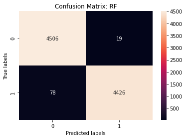

```python
cm = confusion_matrix(y_test, predTest)
ax = plt.subplot()
sns.heatmap(cm, annot=True, fmt='g', ax=ax);

# labels, title and ticks
ax.set_xlabel('Predicted labels');ax.set_ylabel('True labels');
ax.set_title('Confusion Matrix: RF');
```

```python
Recall = sklearn.metrics.recall_score(y_true = y_test, y_pred = predTest)
tn, fp, fn, tp = confusion_matrix(y_true = y_test, y_pred = predTest).ravel()
specificity = tn / (tn+fp)
precision = metrics.precision_score(y_true = y_test, y_pred = predTest)
BalancedAccuracy = metrics.balanced_accuracy_score(y_true = y_test, y_pred = predTest, sample_weight=None, adjusted=False)
F1Score = sklearn.metrics.f1_score(y_true = y_test, y_pred = predTest)
print('Recall: {}, Specificity: {}, Precision: {}, Balanced Accuracy: {}, F1 Score: {}'.format(Recall, specificity, precision, BalancedAccuracy, F1Score))
```

```
Recall: 0.9826820603907638, Specificity: 0.9958011049723757, Precision: 0.9957255343082114, Balanced Accuracy: 0.9892415826815697, F1 Score: 0.9891608000893954
```

```python
columns = X.columns
feat_import = clf.feature_importances_
res = "\n".join("{} {}".format(x, y) for x, y in zip(columns, feat_import))
print(res)
```

```
Shotgun 0.013399155215446096
Angle 0.0035653048217594695
Comeback 0.01355590803307876
Corner 0.023921751621124632
Curl 0.05062953756975193
Dig 0.03898918842515856
Drag 0.02765596549557015
Flat 0.03454473203318191
Go 0.05218858114504204
No Intended Route 0.04353614017009096
Other 0.024057318951579847
Out 0.04008169899894693
Post 0.041863532243987325
Screen 0.024115506443125816
Slant 0.024148347255223593
Swing 0.03701301165305355
count_routes 0.036779871606803176
Yardline 0.12263246602720217
DropType_Basic Screen 0.0030126557814759247
DropType_Other 0.00014354513950720957
DropType_RPO 0.006091812621138327
DropType_Rollout 0.016632430397974858
DropType_Spike 6.33192126536217e-05
DropType_Stepback 0.008724738235144655
DropType_Trick 0.0005897054539423938
CoverageScheme_Combination 0.002823787184200416
CoverageScheme_Cover 0 0.018464592698217437
CoverageScheme_Cover 1 0.057744013296943036
CoverageScheme_Cover 2 0.04490579784377269
CoverageScheme_Cover 3 0.054940879131980445
CoverageScheme_Cover 4 0.04852472242869596
CoverageScheme_Cover 6 0.018009960288313146
CoverageScheme_Man Cover 2 0.028092011833654958
CoverageScheme_Other 0.0010071674430924841
CoverageScheme_Prevent 0.004072945000451716
CoverageScheme_Screen 0.02113827234503154
CoverageScheme_Spike 8.473429119437207e-05
CoverageScheme_Tampa 2 0.012254891662487968
```

```python
clf = AdaBoostClassifier()
parameters = {
    'learning_rate': [0.01, 0.02, 0.05, 0.08, 0.1, 0.2, 0.5, 0.8, 1, 2],
    'n_estimators' : [5, 10, 20, 25, 50, 75, 100]
}
cv = GridSearchCV(clf, parameters, cv=3)
cv.fit(X_train, y_train)

print_results(cv)
```

```
BEST PARAMS: {'learning_rate': 1, 'n_estimators': 100}

0.584 (+/-0.002) for {'learning_rate': 0.01, 'n_estimators': 5}
0.584 (+/-0.002) for {'learning_rate': 0.01, 'n_estimators': 10}
0.584 (+/-0.002) for {'learning_rate': 0.01, 'n_estimators': 20}
0.584 (+/-0.002) for {'learning_rate': 0.01, 'n_estimators': 25}
0.612 (+/-0.036) for {'learning_rate': 0.01, 'n_estimators': 50}
0.674 (+/-0.034) for {'learning_rate': 0.01, 'n_estimators': 75}
0.7 (+/-0.007) for {'learning_rate': 0.01, 'n_estimators': 100}
0.584 (+/-0.002) for {'learning_rate': 0.02, 'n_estimators': 5}
0.584 (+/-0.002) for {'learning_rate': 0.02, 'n_estimators': 10}
0.593 (+/-0.026) for {'learning_rate': 0.02, 'n_estimators': 20}
0.618 (+/-0.02) for {'learning_rate': 0.02, 'n_estimators': 25}
0.702 (+/-0.008) for {'learning_rate': 0.02, 'n_estimators': 50}
0.729 (+/-0.001) for {'learning_rate': 0.02, 'n_estimators': 75}
0.739 (+/-0.008) for {'learning_rate': 0.02, 'n_estimators': 100}
0.584 (+/-0.002) for {'learning_rate': 0.05, 'n_estimators': 5}
0.626 (+/-0.021) for {'learning_rate': 0.05, 'n_estimators': 10}
0.694 (+/-0.012) for {'learning_rate': 0.05, 'n_estimators': 20}
0.705 (+/-0.011) for {'learning_rate': 0.05, 'n_estimators': 25}
0.745 (+/-0.008) for {'learning_rate': 0.05, 'n_estimators': 50}
0.763 (+/-0.004) for {'learning_rate': 0.05, 'n_estimators': 75}
0.784 (+/-0.015) for {'learning_rate': 0.05, 'n_estimators': 100}
0.623 (+/-0.056) for {'learning_rate': 0.08, 'n_estimators': 5}
0.672 (+/-0.027) for {'learning_rate': 0.08, 'n_estimators': 10}
0.725 (+/-0.019) for {'learning_rate': 0.08, 'n_estimators': 20}
0.738 (+/-0.007) for {'learning_rate': 0.08, 'n_estimators': 25}
0.776 (+/-0.013) for {'learning_rate': 0.08, 'n_estimators': 50}
0.801 (+/-0.018) for {'learning_rate': 0.08, 'n_estimators': 75}
0.829 (+/-0.006) for {'learning_rate': 0.08, 'n_estimators': 100}
0.623 (+/-0.056) for {'learning_rate': 0.1, 'n_estimators': 5}
0.696 (+/-0.043) for {'learning_rate': 0.1, 'n_estimators': 10}
0.742 (+/-0.004) for {'learning_rate': 0.1, 'n_estimators': 20}
0.745 (+/-0.006) for {'learning_rate': 0.1, 'n_estimators': 25}
0.777 (+/-0.008) for {'learning_rate': 0.1, 'n_estimators': 50}
0.823 (+/-0.006) for {'learning_rate': 0.1, 'n_estimators': 75}
0.844 (+/-0.002) for {'learning_rate': 0.1, 'n_estimators': 100}
0.675 (+/-0.022) for {'learning_rate': 0.2, 'n_estimators': 5}
0.735 (+/-0.003) for {'learning_rate': 0.2, 'n_estimators': 10}
0.771 (+/-0.015) for {'learning_rate': 0.2, 'n_estimators': 20}
```

[output cut: 17 more lines]

```
0.962 (+/-0.002) for {'learning_rate': 0.8, 'n_estimators': 100}
0.719 (+/-0.015) for {'learning_rate': 1, 'n_estimators': 5}
0.785 (+/-0.001) for {'learning_rate': 1, 'n_estimators': 10}
0.862 (+/-0.005) for {'learning_rate': 1, 'n_estimators': 20}
0.886 (+/-0.006) for {'learning_rate': 1, 'n_estimators': 25}
0.946 (+/-0.004) for {'learning_rate': 1, 'n_estimators': 50}
0.965 (+/-0.003) for {'learning_rate': 1, 'n_estimators': 75}
0.97 (+/-0.004) for {'learning_rate': 1, 'n_estimators': 100}
0.584 (+/-0.002) for {'learning_rate': 2, 'n_estimators': 5}
0.528 (+/-0.158) for {'learning_rate': 2, 'n_estimators': 10}
0.528 (+/-0.158) for {'learning_rate': 2, 'n_estimators': 20}
0.584 (+/-0.002) for {'learning_rate': 2, 'n_estimators': 25}
0.528 (+/-0.158) for {'learning_rate': 2, 'n_estimators': 50}
0.584 (+/-0.002) for {'learning_rate': 2, 'n_estimators': 75}
0.528 (+/-0.158) for {'learning_rate': 2, 'n_estimators': 100}
```

```python
clf = AdaBoostClassifier(learning_rate = 1, n_estimators = 100)
clf.fit(X_train, y_train)
predTrain = clf.predict(X_train)
TrainAcc = metrics.accuracy_score(y_true = y_train, y_pred = predTrain)
predTest = clf.predict(X_test)
TestAcc = metrics.accuracy_score(y_true = y_test, y_pred = predTest)
print('The training accuracy is {}, and the testing accuracy is {}'.format(TrainAcc, TestAcc))
```

```
The training accuracy is 0.9707956433450249, and the testing accuracy is 0.9689888138221286
```

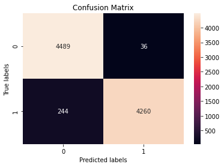

```python
cm = confusion_matrix(y_test, predTest)
ax = plt.subplot()
sns.heatmap(cm, annot=True, fmt='g', ax=ax);  #annot=True to annotate cells, ftm='g' to disable scientific notation

# labels, title and ticks
ax.set_xlabel('Predicted labels');ax.set_ylabel('True labels');
ax.set_title('Confusion Matrix');
```

```python
Recall = sklearn.metrics.recall_score(y_true = y_test, y_pred = predTest)
tn, fp, fn, tp = confusion_matrix(y_true = y_test, y_pred = predTest).ravel()
specificity = tn / (tn+fp)
precision = metrics.precision_score(y_true = y_test, y_pred = predTest)
BalancedAccuracy = metrics.balanced_accuracy_score(y_true = y_test, y_pred = predTest, sample_weight=None, adjusted=False)
F1Score = sklearn.metrics.f1_score(y_true = y_test, y_pred = predTest)
print('Recall: {}, Specificity: {}, Precision: {}, Balanced Accuracy: {}, F1 Score: {}'.format(Recall, specificity, precision, BalancedAccuracy, F1Score))
```

```
Recall: 0.9458259325044405, Specificity: 0.9920441988950276, Precision: 0.9916201117318436, Balanced Accuracy: 0.968935065699734, F1 Score: 0.9681818181818183
```

```python
columns = Int_route_combo.columns
feat_import = clf.feature_importances_
res = "\n".join("{} {}".format(x, y) for x, y in zip(columns, feat_import))
print(res)
```

```
Shotgun 0.0
InterceptionOnPlay 0.01
Angle 0.02
Comeback 0.04
Corner 0.1
Curl 0.07
Dig 0.04
Drag 0.05
Flat 0.09
Go 0.04
No Intended Route 0.02
Other 0.06
Out 0.06
Post 0.02
Screen 0.05
Slant 0.04
Swing 0.06
count_routes 0.0
Yardline 0.0
DropType_Basic Screen 0.0
DropType_Other 0.01
DropType_RPO 0.01
DropType_Rollout 0.0
DropType_Spike 0.0
DropType_Stepback 0.0
DropType_Trick 0.01
CoverageScheme_Combination 0.01
CoverageScheme_Cover 0 0.04
CoverageScheme_Cover 1 0.02
CoverageScheme_Cover 2 0.04
CoverageScheme_Cover 3 0.03
CoverageScheme_Cover 4 0.01
CoverageScheme_Cover 6 0.01
CoverageScheme_Man Cover 2 0.0
CoverageScheme_Other 0.01
CoverageScheme_Prevent 0.02
CoverageScheme_Screen 0.0
CoverageScheme_Spike 0.01
```

## Classification Results

This result shows that classification could be used to determine which situations could result in an interception, however over or under sampling would likely be necessary to address class imbalance issues, as it is much more likely an interception does not occur on a play.

## Defensive success Classification Results

```python
#logistic regression model result
proba_pred = logCLF.predict_proba(defenseDF)

#Defensive success probability
defense_success = pd.DataFrame(proba_pred[:,1])
defense_success = defense_success.reset_index()

#routes
off_routes = defenseDF.iloc[:, 6:21]
off_routes = off_routes.reset_index()

#coverage
defense_coverage = route_combo.iloc[:, 28]
defense_coverage = defense_coverage.reset_index()

# combine all of those variables into one dataframe
defense_success_df = pd.concat([off_routes, defense_coverage, defense_success], axis = 1).rename(columns = {0:'DefensiveSuccess'}).drop('index', axis = 1)
```

```python
defense_success_df
```

|  | Angle | Comeback | Corner | Curl | Dig | Drag | Flat | Go | No Intended Route | Other | Out | Post | Screen | Slant | Swing | CoverageScheme | DefensiveSuccess |
| --- | --- | --- | --- | --- | --- | --- | --- | --- | --- | --- | --- | --- | --- | --- | --- | --- | --- |
| 0 | 0 | 0 | 0 | 2 | 0 | 0 | 0 | 2 | 0 | 0 | 1 | 0 | 0 | 0 | 0 | Cover 1 | 0.478991 |
| 1 | 0 | 0 | 0 | 1 | 1 | 0 | 0 | 1 | 0 | 0 | 0 | 0 | 0 | 0 | 1 | Cover 2 | 0.607451 |
| 2 | 0 | 0 | 0 | 1 | 1 | 0 | 0 | 1 | 0 | 0 | 0 | 0 | 0 | 1 | 1 | Cover 1 | 0.494739 |
| 3 | 0 | 0 | 0 | 0 | 0 | 1 | 0 | 0 | 1 | 0 | 0 | 0 | 0 | 0 | 1 | Screen | 0.552681 |
| 4 | 0 | 0 | 1 | 2 | 0 | 0 | 0 | 0 | 0 | 0 | 0 | 1 | 0 | 1 | 0 | Cover 2 | 0.360589 |
| ... | ... | ... | ... | ... | ... | ... | ... | ... | ... | ... | ... | ... | ... | ... | ... | ... | ... |
| 18418 | 0 | 0 | 0 | 0 | 0 | 0 | 1 | 0 | 0 | 1 | 0 | 0 | 0 | 3 | 0 | Cover 3 | 0.367326 |
| 18419 | 0 | 0 | 0 | 2 | 0 | 0 | 0 | 1 | 0 | 0 | 1 | 1 | 0 | 0 | 0 | Man Cover 2 | 0.461208 |
| 18420 | 0 | 0 | 0 | 0 | 0 | 0 | 1 | 0 | 0 | 0 | 1 | 0 | 0 | 3 | 0 | Cover 1 | 0.443703 |
| 18421 | 0 | 0 | 0 | 0 | 0 | 1 | 0 | 1 | 0 | 0 | 1 | 0 | 0 | 2 | 0 | Cover 2 | 0.333394 |
| 18422 | 0 | 0 | 0 | 0 | 0 | 1 | 0 | 0 | 0 | 0 | 0 | 0 | 0 | 0 | 0 | Screen | 0.621710 |

18423 rows × 17 columns

```python
for index, row in defense_success_df.iterrows():
    temp_str = ''

    angle = row['Angle'] * 'Angle, '
    comeback = row['Comeback'] * 'Comeback, '
    corner = row['Corner'] * 'Corner, '
    curl = row['Curl'] * 'Curl, '
    dig = row['Dig'] * 'Dig, '
    drag = row['Drag'] * 'Drag, '
    flat = row['Flat'] * 'Flat, '
    go = row['Go'] * 'Go, '
    other = row['Other'] * 'Other, '
    out = row['Out'] * 'Out, '
    post = row['Post'] * 'Post, '
    screen = row['Screen'] * 'Screen, '
    slant = row['Slant'] * 'Slant, '

    temp_str = str(angle + comeback + corner + curl + dig + drag + flat + go + other + out + post + screen + slant)
    temp_str = temp_str[:-2]
    defense_success_df.at[index, 'route_combo'] = temp_str

    DefensiveSuccess_means = defense_success_df.groupby(['route_combo', 'CoverageScheme'], as_index=False)['DefensiveSuccess'].mean()
    defensive_route_counts = defense_success_df.groupby(['route_combo', 'CoverageScheme'], as_index=False).size()
    defensiveSuccess_df = pd.concat([DefensiveSuccess_means, defensive_route_counts], axis = 1)
    defensiveSuccess_df = defensiveSuccess_df.loc[:,~defensiveSuccess_df.columns.duplicated()]

    defensiveSuccess_df['DefensiveSuccess'] = round(defensiveSuccess_df['DefensiveSuccess']*100, 1)
    # filter on route combinations with a minimum of 20 plays
    defensive_final_df = defensiveSuccess_df.loc[defensiveSuccess_df['size'] >= 20]
    defensive_final_df.sort_values('DefensiveSuccess', ascending = False).head(10)
```

```python
DefensiveSuccess_means = defense_success_df.groupby(['route_combo', 'CoverageScheme'], as_index=False)['DefensiveSuccess'].mean()
defensive_route_counts = defense_success_df.groupby(['route_combo', 'CoverageScheme'], as_index=False).size()
defensiveSuccess_df = pd.concat([DefensiveSuccess_means, defensive_route_counts], axis = 1)
defensiveSuccess_df = defensiveSuccess_df.loc[:,~defensiveSuccess_df.columns.duplicated()]

defensiveSuccess_df['DefensiveSuccess'] = round(defensiveSuccess_df['DefensiveSuccess']*100, 1)

# filter on route combinations with a minimum of 20 plays
defensive_final_df = defensiveSuccess_df.loc[defensiveSuccess_df['size'] >= 20]
defensive_final_df.sort_values('DefensiveSuccess', ascending = False).head(10)
```

|  | route_combo | CoverageScheme | DefensiveSuccess | size |
| --- | --- | --- | --- | --- |
| 6907 | Go, Go, Go, Screen | Screen | 62.0 | 23 |
| 5019 | Dig, Dig, Go, Out | Cover 1 | 61.4 | 23 |
| 6859 | Go, Go, Go, Go, Screen | Screen | 61.4 | 22 |
| 5321 | Dig, Drag, Go, Post | Cover 1 | 60.8 | 24 |
| 5767 | Dig, Go, Out, Post | Cover 1 | 60.3 | 22 |
| 6999 | Go, Go, Screen | Screen | 59.3 | 25 |
| 7127 | Go, Post, Screen | Screen | 58.6 | 27 |
| 7317 | Screen, Screen | Screen | 58.3 | 149 |
| 7285 | Post, Post | Cover 1 | 58.2 | 26 |
| 7300 | Post, Screen | Screen | 57.6 | 41 |

From the table above, Screen and Cover 1 were two of the best defensive coverages as they made up of the top 10 highest success rates. The Screen coverage is specifically against "Go" and "Screen" route combination, while Cover 1 is specifically against route with a combination of "Go", "Post", "Dig" and "Out".

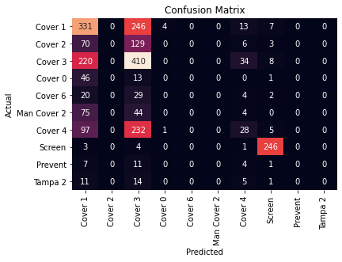

```python
#SVC Model
svc_cm_labels = svc_y_fact[1]
svcmatrix = confusion_matrix(svc_y_test, svc_pred)

cm_array = pd.DataFrame(svcmatrix, index=svc_cm_labels, columns=svc_cm_labels)

sns.heatmap(cm_array, annot=True, square=False, fmt='', cbar=False)
plt.title('Confusion Matrix')
plt.ylabel('Actual')
plt.xlabel('Predicted')
plt.show()
```

The confusion matrix of the SVC multi-class indicated that all cover schemes with a small sample size were miss classified and classified between Cover 1 and Cover 3. With this new information, we can assume that Cover 1 and Cover 3 are distinctive, while the other cover schemes are derived from the two classes. Thus, the next step is to covert other cover schemes into Cover 1 or Cover 3 based on their similarity.

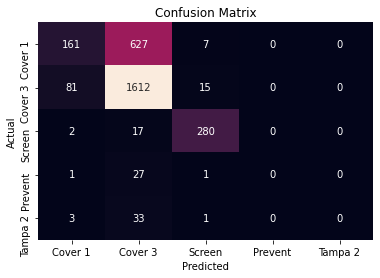

```python
#SVC Model - Reduced Multi-class
reduced_cm_labels = reduced_y_fact[1]
svcmatrix = confusion_matrix(reduced_y_test, reduced_pred)

cm_array = pd.DataFrame(svcmatrix, index=reduced_cm_labels, columns=reduced_cm_labels)

sns.heatmap(cm_array, annot=True, square=False, fmt='', cbar=False)
plt.title('Confusion Matrix')
plt.ylabel('Actual')
plt.xlabel('Predicted')
plt.show()
```

The confusion matrix of the SVC reduced multi-class indicated that Cover 1 and Cover 3 remain an issue for the miss classification. It indicated that cover schemes might have more similarities. Combining multiple cover classes into one would lead to heavily skewed toward the cover class with the most sample. With this new information, we will need to introduce more variables that can describe the function of different types of cover coverage schemes.

# 5. Conclusions

### Answering the research questions

For our research questions, we were able to provide some insights using the route combos and the defensive coverages. Other variables didn't show as much significance however the findings from the analysis are still useful nonetheless.

1. We found that the most effective route combination was the Curl, Curl, Go, Out, Swing. This route combination opens up space by sending one receiver deep and providing different length of passes to seperate the defense. The swing part of the route gives the QB a checkdown in case of pressure.

> We also found that the Corner, Drag, Post was specifically effective against the Cover 3 defense. The routes send 2 players behind the inital zone and 1 on the inside of the zone. If the 2 deeper routes are covered, there is an opportunity for the QB to still get the ball upfield and into a receiver's hands.
1. Dropback type didn't have an impact on whether or not a play was successful. While this doesn't help provide insights on how to better call plays, it can help decision makers know they can play calls based on their playger strengths and it shouldn't have a negative impact. For example, a QB that is more athletic may benefit from a RPO compared to the standard stepback and that decision alone doesn't determine if the play will be successful.
1. When looking at the defensive coverages, we found that Cover 0, 2, and 3 were the most influential in determining success. Defensive coordinators can benefit from this knowledge since they can better plan for a game. Cover 2 can result in double coverages with a corner covering a WR with help from the Safety over the top. This allows a CB to be more aggressive which can lead to more interceptions.
1. The most efficient coverages were Screen and Cover 1. Screen plays are often used to exploit the defense being further back in coverage to allow time for blockers to get into position. However, if the defense is in a screen defense, the plays don't have time to setup and can be stopped early or cause turnovers.

### Additional Opportunities

With additional time, we could have looked closer at play combinations, i.e an offense running 2 pass plays before a run or running the ball before a play action play to see if the conventional wisedom upholds or if defenses are getting smarter.

We could also look into individual players and how they performed given specific variables (i.e. are certain QBs better at RPO than others).

# 6. References

The data we used came from the Sports Info Solutions data analytics competition. It can be found at the following link on Github under the Data folder: https://github.com/SportsInfoSolutions/AnalyticsChallenge2021

Information regarding addressing class imbalance was found from this article about the package SMOTE: https://machinelearningmastery.com/smote-oversampling-for-imbalanced-classification/